Skip to content

Microbiome workshopStudent handbook

Run the commands yourself

# Microbiome workshop: step-by-step analysis

A complete run of the workflow from raw 16S reads to diversity statistics: each command, what it printed, every plot, and how to read them.

The data set: 30 samplescondition C1 condition C2

Study G1

S04S07S17S02S11S21

99% identity

Study G2

S06S19S28S13S18S29

99% identity

Study G3

S03S22S25S05S12S14

99% identity

Study G4

S08S10S23S09S26S27

99% identity

Study G5

S15S16S24S01S20S30

97% identity

Five study groups, each with three samples per condition. Sample names are neutral codes. One group was filtered at a different identity threshold, so compare groups with care.

## How to use this page

1. This is the worked answer: every command of the workflow with the output and plots from a complete test run.
2. Each numbered step shows the R code first and what it printed underneath. Long outputs are folded; select **Show** to open them.
3. Coloured boxes explain the idea behind a section; captions under the plots explain how to read them.
4. Your own numbers should match these if you used the same data and seed. Small differences in file paths and timings are normal.

## Read this before interpreting anything

The reads were selected because they match a bacterial reference panel, each comparison has three samples per condition, and one study group used a different identity threshold. Treat every result as **exploratory**: good for learning the method, not for biological conclusions.

## Set up the workshop

**The idea.** Before any analysis, R needs its packages, the right copy of mothur for your computer, and the data unpacked into a fresh folder. Nothing biological happens yet; this section makes sure everyone in the room starts from exactly the same files.

- **Packages.** `phyloseq` stores microbiome data, `vegan` calculates diversity and distances, `ggplot2` and `patchwork` draw and combine plots.
- **Checksums.** Lines with `digest(..., algo = "sha256")` compute a fingerprint of a file and compare it with the expected one. If a download was cut short or a file was edited, the fingerprints differ and `stopifnot()` halts the run instead of letting you analyse damaged data.
- **Run folder.** Each run gets its own time-stamped folder under `runs/`, so you can repeat the workshop without overwriting earlier work.
- **reads.files.** A three-column table (sample, forward file, reverse file) that tells mothur which two FASTQ files belong to each sample.

Run the commands in order in RStudio. Press Copy and paste the complete command. Package preparation is a prerequisite.

1

Set the working directory to the workshop folder. The path is found automatically, so nothing needs to be typed.

Every later command uses paths such as `scripts/`, `metadata/` and `vendor/` that are relative to the workshop folder. If R is already there (as it is when you knit, or when the folder is open as an RStudio project), nothing changes. Otherwise the folder is taken from `workflow.Rmd` open in RStudio; if that is not possible, a file window opens and you select `workflow.Rmd` in the workshop folder. The `stopifnot()` line stops with an error if the folder is not the right one, and `getwd()` prints the folder in use.

R code

```
if (!file.exists("workflow.Rmd")) {
  open_file <- if (requireNamespace("rstudioapi", quietly = TRUE) && rstudioapi::isAvailable())
    rstudioapi::getSourceEditorContext()$path else ""
  if (!nzchar(open_file) || basename(open_file) != "workflow.Rmd") open_file <- file.choose()
  setwd(dirname(normalizePath(open_file)))
}
stopifnot(file.exists("workflow.Rmd"), dir.exists("scripts"), dir.exists("vendor"))
getwd()
```

2

Install and check the required packages.

R code

```
source("scripts/prepare_packages.R")
```

Output

```
Checking R packages in a separate process. Please keep RStudio open.
```

Output

```
Package setup finished. Open workflow.Rmd and run its chunks from the top.
```

3

Check that every package the workflow needs is installed, then load them all. This is the only cell that loads packages; no later step calls library().

The preparation command, `source("scripts/prepare_packages.R")`, already installs anything that is missing. This cell confirms it worked: if a package is absent it stops with the package name instead of failing later with a confusing error. `phyloseq` stores the data, `vegan` calculates diversity and PERMANOVA, `ggplot2` and `patchwork` draw the figures, `MetaQC` checks whether the studies can be combined, `ANCOMBC` tests differential abundance and `metafor` runs the meta-analyses.

R code

```
packages <- c("phyloseq", "vegan", "ggplot2", "patchwork", "ANCOMBC", "metafor", "MetaQC", "jsonlite", "digest", "processx")
missing_packages <- packages[!vapply(packages, requireNamespace, logical(1), quietly = TRUE)]
if (length(missing_packages)) stop("Not installed: ", paste(missing_packages, collapse = ", "), ". Run source(\"scripts/prepare_packages.R\") again.")
library(phyloseq)
library(vegan)
library(ggplot2)
library(patchwork)
library(ANCOMBC)
library(metafor)
suppressPackageStartupMessages(library(MetaQC))
```

4

Check the supplied files.

R code

```
manifest <- jsonlite::read_json("resources.json", simplifyVector = TRUE)
```

5

Read the operating system.

R code

```
system_name <- Sys.info()[["sysname"]]
```

6

Read the R processor architecture.

R code

```
architecture <- ifelse(tolower(R.version$arch) %in% c("aarch64", "arm64"), "arm64", "x86_64")
```

7

Choose the mothur archive for this system.

R code

```
asset <- switch(system_name, Darwin = paste0("Mothur.OSX_", architecture, ".zip"), Linux = paste0("Mothur.linux_", architecture, ".noReadline.zip"), Windows = if (architecture == "x86_64") "Mothur.win.zip" else stop("Windows ARM is not supported"), stop("Unsupported operating system"))
```

8

Confirm the mothur archive is unchanged.

R code

```
stopifnot(digest::digest(file = file.path("vendor", asset), algo = "sha256", serialize = FALSE) == manifest$resources$sha256[match(asset, manifest$resources$name)])
```

9

Create a folder for mothur.

R code

```
runtime_dir <- file.path(".tools", sub("\\.zip$", "", asset))
```

10

Create the program folder.

R code

```
dir.create(runtime_dir, recursive = TRUE, showWarnings = FALSE)
```

11

Extract mothur.

R code

```
utils::unzip(file.path("vendor", asset), exdir = runtime_dir)
```

12

Locate the program.

R code

```
mothur <- normalizePath(list.files(runtime_dir, pattern = if (.Platform$OS.type == "windows") "^mothur\\.exe$" else "^mothur$", recursive = TRUE, full.names = TRUE)[1], mustWork = TRUE)
```

13

Allow the program to run on macOS and Linux.

R code

```
if (.Platform$OS.type != "windows") Sys.chmod(mothur, "0755")
```

14

Allow mothur’s helper programs to run.

R code

```
if (.Platform$OS.type != "windows") Sys.chmod(list.files(dirname(mothur), pattern = "^(vsearch|uchime)$", full.names = TRUE), "0755")
```

15

Make the helper programs available.

R code

```
Sys.setenv(PATH = paste(dirname(mothur), Sys.getenv("PATH"), sep = .Platform$path.sep))
```

16

Choose a fresh analysis folder.

R code

```
run_dir <- file.path("runs", paste0("teaching-", format(Sys.time(), "%Y%m%d-%H%M%S")))
```

17

Create the analysis folder.

R code

```
dir.create(run_dir, recursive = TRUE)
```

18

Use its full path.

R code

```
run_dir <- normalizePath(run_dir, mustWork = TRUE)
```

19

Verify the read archive.

R code

```
stopifnot(digest::digest(file = "vendor/workshop_reads.zip", algo = "sha256", serialize = FALSE) == manifest$workshop_reads_sha256)
```

20

Extract the anonymized reads.

R code

```
utils::unzip("vendor/workshop_reads.zip", exdir = run_dir)
```

21

Read the sample list.

R code

```
sample_summary <- read.delim(file.path(run_dir, "filtered_fastq", "summary.tsv"))
```

22

Create the paired-read manifest.

R code

```
read_manifest <- data.frame(sample = sample_summary$sample_id, forward = paste0("filtered_fastq/", sample_summary$sample_id, "_R1.fastq.gz"), reverse = paste0("filtered_fastq/", sample_summary$sample_id, "_R2.fastq.gz"))
```

23

Save the paired-read manifest for mothur.

R code

```
write.table(read_manifest, file.path(run_dir, "reads.files"), sep = "\t", quote = FALSE, row.names = FALSE, col.names = FALSE)
```

24

Verify the SILVA archive.

R code

```
stopifnot(digest::digest(file = "vendor/silva.bacteria.zip", algo = "sha256", serialize = FALSE) == manifest$resources$sha256[match("silva.bacteria.zip", manifest$resources$name)])
```

25

Extract the SILVA reference.

R code

```
utils::unzip("vendor/silva.bacteria.zip", exdir = run_dir)
```

26

Place the alignment where mothur can find it.

R code

```
stopifnot(file.copy(file.path(run_dir, "silva.bacteria", "silva.bacteria.fasta"), file.path(run_dir, "silva.bacteria.fasta")))
```

27

Verify the taxonomy training archive.

R code

```
stopifnot(digest::digest(file = "vendor/trainset9_032012.pds.zip", algo = "sha256", serialize = FALSE) == manifest$resources$sha256[match("trainset9_032012.pds.zip", manifest$resources$name)])
```

28

Extract the taxonomy training files.

R code

```
utils::unzip("vendor/trainset9_032012.pds.zip", exdir = run_dir)
```

## Run mothur commands one by one

**The idea.** mothur is a separate program for processing 16S rRNA gene sequences. Here R starts one mothur session and sends it one command at a time, so you can read what each command prints before moving on.

mothur remembers the most recent file of each type. That is why many commands say `fasta=current` and `count=current`: "use whatever the last step produced". After every command, `get.current()` lists those remembered files; reading that list is the quickest way to check that a step did what you expected.

File names grow as you go. `reads.trim.contigs.good.unique.fasta` reads from left to right as a history: contigs were made, bad ones removed (`good`), duplicates collapsed (`unique`).

In this recorded run the log was sometimes read a moment before mothur had finished writing. An output block can therefore show the messages of the command just before it.

Each command runs in the active mothur session. The following small R steps wait for it and print the output in the Console before you start the next command. A diagnostic get.current command shows the files available to mothur.

29

Choose where to save the mothur output.

R code

```
mothur_log <- file.path(run_dir, "mothur-console.log")
```

30

Start one persistent mothur session from R.

R code

```
mothur_process <- processx::process$new(mothur, stdin = "|", stdout = mothur_log, stderr = "2>&1", wd = run_dir, cleanup = TRUE)
```

31

Start tracking output already shown in the Console.

R code

```
mothur_cursor <- 0L
```

### Assemble and screen reads

**Goal of this stage.** Turn each pair of raw reads into one clean sequence. The forward and reverse reads overlap in the middle of the amplicon; joining them gives a longer, more accurate sequence called a *contig*. Then sequences that are obviously faulty are discarded and identical sequences are collapsed so later steps run faster.

32

**Set the number of processors** set.current

`set.current(processors=4)`

Tells mothur how many processor cores it may use. More cores make the slow steps (alignment, distances) faster. Nothing is analysed yet.

R code that sends the command

```
mothur_process$write_input("set.current(processors=4)\nget.current()\n")
```

**Helper R steps: wait, print, check for errors, remember position**

Wait until this mothur command has completed.

R code

```
repeat { Sys.sleep(0.2); mothur_output <- readLines(mothur_log, warn = FALSE); if (sum(grepl("Current files saved by mothur:", mothur_output, fixed = TRUE)) >= 1) break; if (!mothur_process$is_alive()) stop("Mothur stopped before completing the command") }
```

Print this mothur command’s output in the Console.

R code

```
cat(paste(mothur_output[seq.int(mothur_cursor + 1L, length(mothur_output))], collapse = "\n"))
```

Stop if this command reported an error.

R code

```
stopifnot(!any(grepl("[ERROR]", mothur_output[seq.int(mothur_cursor + 1L, length(mothur_output))], fixed = TRUE)))
```

Remember the output already displayed.

R code

```
mothur_cursor <- length(mothur_output)
```

**mothur output: 52 lines. Show**

```
Mac version

Using ReadLine,Boost,HDF5,GSL
mothur v.1.48.6
Last updated: 7/29/26
by
Patrick D. Schloss

Department of Microbiology & Immunology

University of Michigan
http://www.mothur.org

When using, please cite:
Schloss, P.D., et al., Introducing mothur: Open-source, platform-independent, community-supported software for describing and comparing microbial communities. Appl Environ Microbiol, 2009. 75(23):7537-41.

Distributed under the GNU General Public License

Type 'help()' for information on the commands that are available

For questions and analysis support, please visit our forum at https://forum.mothur.org

Type 'quit()' to exit program

[NOTE]: Setting random seed to 19760620.

Interactive Mode



Using 4 processors.

Current files saved by mothur:
processors=4

Output File Names:
current_files.summary


Current RAM usage: 0.0088501 Gigabytes. Total Ram: 8 Gigabytes.

Current files saved by mothur:
processors=4

Current default directories saved by mothur:
 /private/tmp/workshop30-anonymous/.tools/Mothur.OSX_arm64/mothur/


Current working directory: /private/tmp/workshop30-anonymous/runs/teaching-20261115-184747/

Output File Names:
current_files.summary
```

33

**Fix the random seed** set.seed

`set.seed(seed=20261114)`

Some later steps use random numbers (subsampling, classification bootstraps). Fixing the seed means everyone gets the same numbers and can compare results line by line.

R code that sends the command

```
mothur_process$write_input("set.seed(seed=20261114)\nget.current()\n")
```

**Helper R steps: wait, print, check for errors, remember position**

Wait until this mothur command has completed.

R code

```
repeat { Sys.sleep(0.2); mothur_output <- readLines(mothur_log, warn = FALSE); if (sum(grepl("Current files saved by mothur:", mothur_output, fixed = TRUE)) >= 2) break; if (!mothur_process$is_alive()) stop("Mothur stopped before completing the command") }
```

Print this mothur command’s output in the Console.

R code

```
cat(paste(mothur_output[seq.int(mothur_cursor + 1L, length(mothur_output))], collapse = "\n"))
```

Stop if this command reported an error.

R code

```
stopifnot(!any(grepl("[ERROR]", mothur_output[seq.int(mothur_cursor + 1L, length(mothur_output))], fixed = TRUE)))
```

Remember the output already displayed.

R code

```
mothur_cursor <- length(mothur_output)
```

**mothur output: 18 lines. Show**

```
Setting random seed to 20261114.

Setting random seed to 20261114.


Current RAM usage: 0.00886536 Gigabytes. Total Ram: 8 Gigabytes.

Current files saved by mothur:
processors=4

Current default directories saved by mothur:
 /private/tmp/workshop30-anonymous/.tools/Mothur.OSX_arm64/mothur/


Current working directory: /private/tmp/workshop30-anonymous/runs/teaching-20261115-184747/

Output File Names:
current_files.summary
```

34

**Join forward and reverse reads** make.contigs

`make.contigs(file=reads.files)`

Reads the sample list in `reads.files` and merges each read pair into one contig. Where the two reads overlap and disagree, the base with the better quality score wins. Output: one FASTA file with all contigs and a count table recording which sample each came from.

R code that sends the command

```
mothur_process$write_input("make.contigs(file=reads.files)\nget.current()\n")
```

**Helper R steps: wait, print, check for errors, remember position**

Wait until this mothur command has completed.

R code

```
repeat { Sys.sleep(0.2); mothur_output <- readLines(mothur_log, warn = FALSE); if (sum(grepl("Current files saved by mothur:", mothur_output, fixed = TRUE)) >= 3) break; if (!mothur_process$is_alive()) stop("Mothur stopped before completing the command") }
```

Print this mothur command’s output in the Console.

R code

```
cat(paste(mothur_output[seq.int(mothur_cursor + 1L, length(mothur_output))], collapse = "\n"))
```

Stop if this command reported an error.

R code

```
stopifnot(!any(grepl("[ERROR]", mothur_output[seq.int(mothur_cursor + 1L, length(mothur_output))], fixed = TRUE)))
```

Remember the output already displayed.

R code

```
mothur_cursor <- length(mothur_output)
```

Nothing new had reached the log when this step printed. The messages from this command appear in the next output block.

35

**Summarise the contigs** summary.seqs

`summary.seqs(fasta=current,count=current)`

Prints a table describing the sequences: where they start and end, their length (`NBases`), ambiguous bases (`Ambigs`) and the longest run of one repeated base (`Polymer`). **Check:** most lengths should be close together. Very long contigs usually mean the two reads did not overlap properly.

R code that sends the command

```
mothur_process$write_input("summary.seqs(fasta=current,count=current)\nget.current()\n")
```

**Helper R steps: wait, print, check for errors, remember position**

Wait until this mothur command has completed.

R code

```
repeat { Sys.sleep(0.2); mothur_output <- readLines(mothur_log, warn = FALSE); if (sum(grepl("Current files saved by mothur:", mothur_output, fixed = TRUE)) >= 4) break; if (!mothur_process$is_alive()) stop("Mothur stopped before completing the command") }
```

Print this mothur command’s output in the Console.

R code

```
cat(paste(mothur_output[seq.int(mothur_cursor + 1L, length(mothur_output))], collapse = "\n"))
```

Stop if this command reported an error.

R code

```
stopifnot(!any(grepl("[ERROR]", mothur_output[seq.int(mothur_cursor + 1L, length(mothur_output))], fixed = TRUE)))
```

Remember the output already displayed.

R code

```
mothur_cursor <- length(mothur_output)
```

**mothur output: 388 lines. Show**

```
Using 4 processors.

>>>>>    Processing file pair filtered_fastq/S08_R1.fastq.gz - filtered_fastq/S08_R2.fastq.gz (files 8 of 30)    <<<<<

>>>>>    Processing file pair filtered_fastq/S15_R1.fastq.gz - filtered_fastq/S15_R2.fastq.gz (files 15 of 30)   <<<<<

>>>>>    Processing file pair filtered_fastq/S23_R1.fastq.gz - filtered_fastq/S23_R2.fastq.gz (files 23 of 30)   <<<<<

>>>>>    Processing file pair filtered_fastq/S01_R1.fastq.gz - filtered_fastq/S01_R2.fastq.gz (files 1 of 30)    <<<<<
Making contigs...
Making contigs...
Making contigs...
Making contigs...
1000
1000
1000
1000
1164
Done.

It took 1 secs to assemble 1164 reads.


>>>>>    Processing file pair filtered_fastq/S02_R1.fastq.gz - filtered_fastq/S02_R2.fastq.gz (files 2 of 30)    <<<<<
Making contigs...
338
Done.

It took 0 secs to assemble 338 reads.


>>>>>    Processing file pair filtered_fastq/S03_R1.fastq.gz - filtered_fastq/S03_R2.fastq.gz (files 3 of 30)    <<<<<
Making contigs...
2000
2000
2000
2130
Done.

It took 1 secs to assemble 2130 reads.
```

[output cut: 332 more lines]

```

Current files saved by mothur:
fasta=reads.trim.contigs.fasta
contigsreport=reads.contigs_report
count=reads.contigs.count_table
processors=4

Current default directories saved by mothur:
 /private/tmp/workshop30-anonymous/.tools/Mothur.OSX_arm64/mothur/


Current working directory: /private/tmp/workshop30-anonymous/runs/teaching-20261115-184747/

Output File Names:
current_files.summary
```

36

**Remove poor contigs** screen.seqs

`screen.seqs(fasta=current,count=current,maxambig=0,minlength=400,maxlength=550,maxhomop=8)`

Discards contigs with any ambiguous base (`maxambig=0`), contigs shorter than 400 or longer than 550 bases, and contigs with a run of more than 8 identical bases (`maxhomop=8`). These are almost always sequencing or assembly errors. Run this block once: it stops with a message if the screened file already exists.

R code that sends the command

```
mothur_process$write_input("screen.seqs(fasta=current,count=current,maxambig=0,minlength=400,maxlength=550,maxhomop=8)\nget.current()\n")
```

**Helper R steps: wait, print, check for errors, remember position**

Wait until this mothur command has completed.

R code

```
repeat { Sys.sleep(0.2); mothur_output <- readLines(mothur_log, warn = FALSE); if (sum(grepl("Current files saved by mothur:", mothur_output, fixed = TRUE)) >= 5) break; if (!mothur_process$is_alive()) stop("Mothur stopped before completing the command") }
```

Print this mothur command’s output in the Console.

R code

```
cat(paste(mothur_output[seq.int(mothur_cursor + 1L, length(mothur_output))], collapse = "\n"))
```

Stop if this command reported an error.

R code

```
stopifnot(!any(grepl("[ERROR]", mothur_output[seq.int(mothur_cursor + 1L, length(mothur_output))], fixed = TRUE)))
```

Remember the output already displayed.

R code

```
mothur_cursor <- length(mothur_output)
```

**mothur output: 40 lines. Show**

```
Using reads.contigs.count_table as input file for the count parameter.
Using reads.trim.contigs.fasta as input file for the fasta parameter.

Using 4 processors.

     Start   End NBases  Ambigs  Polymer NumSeqs
Minimum: 1   429 429 0   4   1
2.5%-tile:   1   440 440 0   4   2521
25%-tile:    1   440 440 0   4   25206
Median:  1   447 447 0   4   50411
75%-tile:    1   465 465 0   6   75616
97.5%-tile:  1   480 480 0   7   98301
Maximum: 1   482 482 0   8   100821
Mean:    1   454 454 0   4
# of unique seqs:    100821
total # of seqs: 100821

It took 1 secs to summarize 100821 sequences.

Output File Names:
reads.trim.contigs.summary


Current RAM usage: 0.0886993 Gigabytes. Total Ram: 8 Gigabytes.

Current files saved by mothur:
fasta=reads.trim.contigs.fasta
contigsreport=reads.contigs_report
count=reads.contigs.count_table
processors=4
summary=reads.trim.contigs.summary

Current default directories saved by mothur:
 /private/tmp/workshop30-anonymous/.tools/Mothur.OSX_arm64/mothur/


Current working directory: /private/tmp/workshop30-anonymous/runs/teaching-20261115-184747/

Output File Names:
current_files.summary
```

37

**Summarise the contigs** summary.seqs

`summary.seqs(fasta=current,count=current)`

Prints a table describing the sequences: where they start and end, their length (`NBases`), ambiguous bases (`Ambigs`) and the longest run of one repeated base (`Polymer`). **Check:** most lengths should be close together. Very long contigs usually mean the two reads did not overlap properly.

R code that sends the command

```
mothur_process$write_input("summary.seqs(fasta=current,count=current)\nget.current()\n")
```

**Helper R steps: wait, print, check for errors, remember position**

Wait until this mothur command has completed.

R code

```
repeat { Sys.sleep(0.2); mothur_output <- readLines(mothur_log, warn = FALSE); if (sum(grepl("Current files saved by mothur:", mothur_output, fixed = TRUE)) >= 6) break; if (!mothur_process$is_alive()) stop("Mothur stopped before completing the command") }
```

Print this mothur command’s output in the Console.

R code

```
cat(paste(mothur_output[seq.int(mothur_cursor + 1L, length(mothur_output))], collapse = "\n"))
```

Stop if this command reported an error.

R code

```
stopifnot(!any(grepl("[ERROR]", mothur_output[seq.int(mothur_cursor + 1L, length(mothur_output))], fixed = TRUE)))
```

Remember the output already displayed.

R code

```
mothur_cursor <- length(mothur_output)
```

**mothur output: 136 lines. Show**

```
Using reads.contigs.count_table as input file for the count parameter.
Using reads.trim.contigs.fasta as input file for the fasta parameter.

Using 4 processors.
1000
1000
1000
1000
2000
2000
2000
2000
3000
3000
3000
3000
4000
4000
4000
4000
5000
5000
5000
5000
6000
6000
6000
6000
7000
7000
7000
7000
8000
8000
8000
8000
9000
9000
9000
9000
```

[output cut: 81 more lines]

```
Current files saved by mothur:
fasta=reads.trim.contigs.good.fasta
contigsreport=reads.contigs_report
count=reads.contigs.count_table
processors=4
summary=reads.trim.contigs.summary

Current default directories saved by mothur:
 /private/tmp/workshop30-anonymous/.tools/Mothur.OSX_arm64/mothur/


Current working directory: /private/tmp/workshop30-anonymous/runs/teaching-20261115-184747/

Output File Names:
current_files.summary
```

38

**Collapse identical sequences** unique.seqs

`unique.seqs(fasta=current,count=current)`

Many reads are exact copies of each other. mothur keeps one copy of each and records in the count table how often it occurred in every sample. No information is lost and every later step runs faster.

R code that sends the command

```
mothur_process$write_input("unique.seqs(fasta=current,count=current)\nget.current()\n")
```

**Helper R steps: wait, print, check for errors, remember position**

Wait until this mothur command has completed.

R code

```
repeat { Sys.sleep(0.2); mothur_output <- readLines(mothur_log, warn = FALSE); if (sum(grepl("Current files saved by mothur:", mothur_output, fixed = TRUE)) >= 7) break; if (!mothur_process$is_alive()) stop("Mothur stopped before completing the command") }
```

Print this mothur command’s output in the Console.

R code

```
cat(paste(mothur_output[seq.int(mothur_cursor + 1L, length(mothur_output))], collapse = "\n"))
```

Stop if this command reported an error.

R code

```
stopifnot(!any(grepl("[ERROR]", mothur_output[seq.int(mothur_cursor + 1L, length(mothur_output))], fixed = TRUE)))
```

Remember the output already displayed.

R code

```
mothur_cursor <- length(mothur_output)
```

**mothur output: 40 lines. Show**

```
Using reads.contigs.count_table as input file for the count parameter.
Using reads.trim.contigs.good.fasta as input file for the fasta parameter.

Using 4 processors.

     Start   End NBases  Ambigs  Polymer NumSeqs
Minimum: 1   429 429 0   4   1
2.5%-tile:   1   440 440 0   4   2521
25%-tile:    1   440 440 0   4   25206
Median:  1   447 447 0   4   50411
75%-tile:    1   465 465 0   6   75616
97.5%-tile:  1   480 480 0   7   98301
Maximum: 1   482 482 0   8   100821
Mean:    1   454 454 0   4
# of unique seqs:    100821
total # of seqs: 100821

It took 0 secs to summarize 100821 sequences.

Output File Names:
reads.trim.contigs.good.summary


Current RAM usage: 0.0886993 Gigabytes. Total Ram: 8 Gigabytes.

Current files saved by mothur:
fasta=reads.trim.contigs.good.fasta
contigsreport=reads.contigs_report
count=reads.contigs.count_table
processors=4
summary=reads.trim.contigs.good.summary

Current default directories saved by mothur:
 /private/tmp/workshop30-anonymous/.tools/Mothur.OSX_arm64/mothur/


Current working directory: /private/tmp/workshop30-anonymous/runs/teaching-20261115-184747/

Output File Names:
current_files.summary
```

### Trim the reference and align

**Goal of this stage.** Line every sequence up against a reference alignment (SILVA) so that position 100 in one sequence corresponds to position 100 in every other. Only aligned sequences can be compared fairly. The reference is first trimmed to the region these reads cover, which makes alignment much faster.

39

**Summarise the contigs** summary.seqs

`summary.seqs(fasta=current,count=current)`

Prints a table describing the sequences: where they start and end, their length (`NBases`), ambiguous bases (`Ambigs`) and the longest run of one repeated base (`Polymer`). **Check:** most lengths should be close together. Very long contigs usually mean the two reads did not overlap properly.

R code that sends the command

```
mothur_process$write_input("summary.seqs(fasta=current,count=current)\nget.current()\n")
```

**Helper R steps: wait, print, check for errors, remember position**

Wait until this mothur command has completed.

R code

```
repeat { Sys.sleep(0.2); mothur_output <- readLines(mothur_log, warn = FALSE); if (sum(grepl("Current files saved by mothur:", mothur_output, fixed = TRUE)) >= 8) break; if (!mothur_process$is_alive()) stop("Mothur stopped before completing the command") }
```

Print this mothur command’s output in the Console.

R code

```
cat(paste(mothur_output[seq.int(mothur_cursor + 1L, length(mothur_output))], collapse = "\n"))
```

Stop if this command reported an error.

R code

```
stopifnot(!any(grepl("[ERROR]", mothur_output[seq.int(mothur_cursor + 1L, length(mothur_output))], fixed = TRUE)))
```

Remember the output already displayed.

R code

```
mothur_cursor <- length(mothur_output)
```

**mothur output: 126 lines. Show**

```
Using reads.contigs.count_table as input file for the count parameter.
Using reads.trim.contigs.good.fasta as input file for the fasta parameter.
1000 774
2000 1335
3000 1797
4000 2266
5000 2694
6000 3083
7000 3416
8000 3744
9000 4062
10000    4409
11000    4751
12000    5114
13000    5444
```

[output cut: 111 more lines]

40

**Trim the reference to our region** pcr.seqs

`pcr.seqs(fasta=silva.bacteria.fasta,start=6000,end=26000,keepdots=F)`

The SILVA reference covers the whole 16S gene. This keeps only alignment columns 6000 to 26000, the stretch that includes the V3–V4 region these reads come from. `keepdots=F` removes the padding dots at the ends.

R code that sends the command

```
mothur_process$write_input("pcr.seqs(fasta=silva.bacteria.fasta,start=6000,end=26000,keepdots=F)\nget.current()\n")
```

**Helper R steps: wait, print, check for errors, remember position**

Wait until this mothur command has completed.

R code

```
repeat { Sys.sleep(0.2); mothur_output <- readLines(mothur_log, warn = FALSE); if (sum(grepl("Current files saved by mothur:", mothur_output, fixed = TRUE)) >= 9) break; if (!mothur_process$is_alive()) stop("Mothur stopped before completing the command") }
```

Print this mothur command’s output in the Console.

R code

```
cat(paste(mothur_output[seq.int(mothur_cursor + 1L, length(mothur_output))], collapse = "\n"))
```

Stop if this command reported an error.

R code

```
stopifnot(!any(grepl("[ERROR]", mothur_output[seq.int(mothur_cursor + 1L, length(mothur_output))], fixed = TRUE)))
```

Remember the output already displayed.

R code

```
mothur_cursor <- length(mothur_output)
```

**mothur output: 40 lines. Show**

```
Using reads.trim.contigs.good.count_table as input file for the count parameter.
Using reads.trim.contigs.good.unique.fasta as input file for the fasta parameter.

Using 4 processors.

     Start   End NBases  Ambigs  Polymer NumSeqs
Minimum: 1   429 429 0   4   1
2.5%-tile:   1   440 440 0   4   2521
25%-tile:    1   440 440 0   4   25206
Median:  1   447 447 0   4   50411
75%-tile:    1   465 465 0   6   75616
97.5%-tile:  1   480 480 0   7   98301
Maximum: 1   482 482 0   8   100821
Mean:    1   454 454 0   4
# of unique seqs:    33689
total # of seqs: 100821

It took 0 secs to summarize 100821 sequences.

Output File Names:
reads.trim.contigs.good.unique.summary


Current RAM usage: 0.117874 Gigabytes. Total Ram: 8 Gigabytes.

Current files saved by mothur:
fasta=reads.trim.contigs.good.unique.fasta
contigsreport=reads.contigs_report
count=reads.trim.contigs.good.count_table
processors=4
summary=reads.trim.contigs.good.unique.summary

Current default directories saved by mothur:
 /private/tmp/workshop30-anonymous/.tools/Mothur.OSX_arm64/mothur/


Current working directory: /private/tmp/workshop30-anonymous/runs/teaching-20261115-184747/

Output File Names:
current_files.summary
```

41

**Give the trimmed reference a short name** rename.file

`rename.file(input=silva.bacteria.pcr.fasta,new=silva.v3v4.fasta)`

Renames the trimmed reference to `silva.v3v4.fasta` so later commands are easier to read.

R code that sends the command

```
mothur_process$write_input("rename.file(input=silva.bacteria.pcr.fasta,new=silva.v3v4.fasta)\nget.current()\n")
```

**Helper R steps: wait, print, check for errors, remember position**

Wait until this mothur command has completed.

R code

```
repeat { Sys.sleep(0.2); mothur_output <- readLines(mothur_log, warn = FALSE); if (sum(grepl("Current files saved by mothur:", mothur_output, fixed = TRUE)) >= 10) break; if (!mothur_process$is_alive()) stop("Mothur stopped before completing the command") }
```

Print this mothur command’s output in the Console.

R code

```
cat(paste(mothur_output[seq.int(mothur_cursor + 1L, length(mothur_output))], collapse = "\n"))
```

Stop if this command reported an error.

R code

```
stopifnot(!any(grepl("[ERROR]", mothur_output[seq.int(mothur_cursor + 1L, length(mothur_output))], fixed = TRUE)))
```

Remember the output already displayed.

R code

```
mothur_cursor <- length(mothur_output)
```

**mothur output: 70 lines. Show**

```
Using 4 processors.
1000
1000
1000
1000
2000
2000
2000
2000
3000
3000
3000
3000
3740
3740
3738
3738
[NOTE]: no sequences were bad, removing silva.bacteria.bad.accnos

It took 4 secs to screen 14956 sequences.

Output File Names:
silva.bacteria.pcr.fasta



Current RAM usage: 0.117874 Gigabytes. Total Ram: 8 Gigabytes.

Current files saved by mothur:
fasta=silva.bacteria.pcr.fasta
contigsreport=reads.contigs_report
count=reads.trim.contigs.good.count_table
processors=4
summary=reads.trim.contigs.good.unique.summary

Current default directories saved by mothur:
 /private/tmp/workshop30-anonymous/.tools/Mothur.OSX_arm64/mothur/


Current working directory: /private/tmp/workshop30-anonymous/runs/teaching-20261115-184747/
```

[output cut: 14 more lines]

```
Current files saved by mothur:
fasta=silva.bacteria.pcr.fasta
contigsreport=reads.contigs_report
count=reads.trim.contigs.good.count_table
processors=4
summary=reads.trim.contigs.good.unique.summary

Current default directories saved by mothur:
 /private/tmp/workshop30-anonymous/.tools/Mothur.OSX_arm64/mothur/


Current working directory: /private/tmp/workshop30-anonymous/runs/teaching-20261115-184747/

Output File Names:
current_files.summary
```

42

**Check the trimmed reference** summary.seqs

`summary.seqs(fasta=silva.v3v4.fasta)`

Summarises the trimmed reference. **Check:** all reference sequences should now start and end at the same alignment positions.

R code that sends the command

```
mothur_process$write_input("summary.seqs(fasta=silva.v3v4.fasta)\nget.current()\n")
```

**Helper R steps: wait, print, check for errors, remember position**

Wait until this mothur command has completed.

R code

```
repeat { Sys.sleep(0.2); mothur_output <- readLines(mothur_log, warn = FALSE); if (sum(grepl("Current files saved by mothur:", mothur_output, fixed = TRUE)) >= 11) break; if (!mothur_process$is_alive()) stop("Mothur stopped before completing the command") }
```

Print this mothur command’s output in the Console.

R code

```
cat(paste(mothur_output[seq.int(mothur_cursor + 1L, length(mothur_output))], collapse = "\n"))
```

Stop if this command reported an error.

R code

```
stopifnot(!any(grepl("[ERROR]", mothur_output[seq.int(mothur_cursor + 1L, length(mothur_output))], fixed = TRUE)))
```

Remember the output already displayed.

R code

```
mothur_cursor <- length(mothur_output)
```

Nothing new had reached the log when this step printed. The messages from this command appear in the next output block.

43

**Align sequences to the reference** align.seqs

`align.seqs(fasta=reads.trim.contigs.good.unique.fasta,reference=silva.v3v4.fasta,flip=t)`

Places each unique sequence into the reference alignment. `flip=t` lets mothur try the reverse complement when a sequence aligns badly, which rescues reads that are in the opposite orientation.

R code that sends the command

```
mothur_process$write_input("align.seqs(fasta=reads.trim.contigs.good.unique.fasta,reference=silva.v3v4.fasta,flip=t)\nget.current()\n")
```

**Helper R steps: wait, print, check for errors, remember position**

Wait until this mothur command has completed.

R code

```
repeat { Sys.sleep(0.2); mothur_output <- readLines(mothur_log, warn = FALSE); if (sum(grepl("Current files saved by mothur:", mothur_output, fixed = TRUE)) >= 12) break; if (!mothur_process$is_alive()) stop("Mothur stopped before completing the command") }
```

Print this mothur command’s output in the Console.

R code

```
cat(paste(mothur_output[seq.int(mothur_cursor + 1L, length(mothur_output))], collapse = "\n"))
```

Stop if this command reported an error.

R code

```
stopifnot(!any(grepl("[ERROR]", mothur_output[seq.int(mothur_cursor + 1L, length(mothur_output))], fixed = TRUE)))
```

Remember the output already displayed.

R code

```
mothur_cursor <- length(mothur_output)
```

Nothing new had reached the log when this step printed. The messages from this command appear in the next output block.

44

**Summarise the contigs** summary.seqs

`summary.seqs(fasta=current,count=current)`

Prints a table describing the sequences: where they start and end, their length (`NBases`), ambiguous bases (`Ambigs`) and the longest run of one repeated base (`Polymer`). **Check:** most lengths should be close together. Very long contigs usually mean the two reads did not overlap properly.

R code that sends the command

```
mothur_process$write_input("summary.seqs(fasta=current,count=current)\nget.current()\n")
```

**Helper R steps: wait, print, check for errors, remember position**

Wait until this mothur command has completed.

R code

```
repeat { Sys.sleep(0.2); mothur_output <- readLines(mothur_log, warn = FALSE); if (sum(grepl("Current files saved by mothur:", mothur_output, fixed = TRUE)) >= 13) break; if (!mothur_process$is_alive()) stop("Mothur stopped before completing the command") }
```

Print this mothur command’s output in the Console.

R code

```
cat(paste(mothur_output[seq.int(mothur_cursor + 1L, length(mothur_output))], collapse = "\n"))
```

Stop if this command reported an error.

R code

```
stopifnot(!any(grepl("[ERROR]", mothur_output[seq.int(mothur_cursor + 1L, length(mothur_output))], fixed = TRUE)))
```

Remember the output already displayed.

R code

```
mothur_cursor <- length(mothur_output)
```

**mothur output: 42 lines. Show**

```
Using 4 processors.

     Start   End NBases  Ambigs  Polymer NumSeqs
Minimum: 92  19515   482 0   3   1
2.5%-tile:   92  19518   503 0   4   374
25%-tile:    92  19518   506 0   4   3740
Median:  92  19518   525 0   5   7479
75%-tile:    92  19518   528 0   5   11218
97.5%-tile:  92  19518   530 1   6   14583
Maximum: 92  19534   570 5   9   14956
Mean:    92  19518   518 0   4
# of Seqs:   14956

It took 1 secs to summarize 14956 sequences.

Output File Names:
silva.v3v4.summary


Current RAM usage: 0.117874 Gigabytes. Total Ram: 8 Gigabytes.

Current files saved by mothur:
fasta=silva.v3v4.fasta
contigsreport=reads.contigs_report
count=reads.trim.contigs.good.count_table
processors=4
summary=silva.v3v4.summary

Current default directories saved by mothur:
 /private/tmp/workshop30-anonymous/.tools/Mothur.OSX_arm64/mothur/


Current working directory: /private/tmp/workshop30-anonymous/runs/teaching-20261115-184747/

Output File Names:
current_files.summary


Using 4 processors.

Reading in the silva.v3v4.fasta template sequences...
```

45

**Keep sequences that cover the same region** screen.seqs

`screen.seqs(fasta=current,count=current,optimize=start-end,criteria=95)`

`optimize=start-end, criteria=95` finds the start and end positions that 95% of sequences share and removes sequences that start later or end earlier. What remains overlaps the same part of the gene. Run this block once: it stops with a message if the screened file already exists.

R code that sends the command

```
mothur_process$write_input("screen.seqs(fasta=current,count=current,optimize=start-end,criteria=95)\nget.current()\n")
```

**Helper R steps: wait, print, check for errors, remember position**

Wait until this mothur command has completed.

R code

```
repeat { Sys.sleep(0.2); mothur_output <- readLines(mothur_log, warn = FALSE); if (sum(grepl("Current files saved by mothur:", mothur_output, fixed = TRUE)) >= 14) break; if (!mothur_process$is_alive()) stop("Mothur stopped before completing the command") }
```

Print this mothur command’s output in the Console.

R code

```
cat(paste(mothur_output[seq.int(mothur_cursor + 1L, length(mothur_output))], collapse = "\n"))
```

Stop if this command reported an error.

R code

```
stopifnot(!any(grepl("[ERROR]", mothur_output[seq.int(mothur_cursor + 1L, length(mothur_output))], fixed = TRUE)))
```

Remember the output already displayed.

R code

```
mothur_cursor <- length(mothur_output)
```

**mothur output: 69 lines. Show**

```
It took 2 to read  14956 sequences.

Aligning sequences from reads.trim.contigs.good.unique.fasta ...
1000
1000
1000
1000
2000
2000
2000
2000
3000
3000
3000
3000
4000
4000
4000
4000
5000
5000
5000
5000
6000
6000
6000
6000
7000
7000
7000
7000
8000
8000
8000
8000
8407
8452
8417
8413
It took 44 secs to align 33689 sequences.
```

[output cut: 14 more lines]

```
Current files saved by mothur:
fasta=reads.trim.contigs.good.unique.align
contigsreport=reads.contigs_report
count=reads.trim.contigs.good.count_table
processors=4
summary=silva.v3v4.summary

Current default directories saved by mothur:
 /private/tmp/workshop30-anonymous/.tools/Mothur.OSX_arm64/mothur/


Current working directory: /private/tmp/workshop30-anonymous/runs/teaching-20261115-184747/

Output File Names:
current_files.summary
```

46

**Summarise the contigs** summary.seqs

`summary.seqs(fasta=current,count=current)`

Prints a table describing the sequences: where they start and end, their length (`NBases`), ambiguous bases (`Ambigs`) and the longest run of one repeated base (`Polymer`). **Check:** most lengths should be close together. Very long contigs usually mean the two reads did not overlap properly.

R code that sends the command

```
mothur_process$write_input("summary.seqs(fasta=current,count=current)\nget.current()\n")
```

**Helper R steps: wait, print, check for errors, remember position**

Wait until this mothur command has completed.

R code

```
repeat { Sys.sleep(0.2); mothur_output <- readLines(mothur_log, warn = FALSE); if (sum(grepl("Current files saved by mothur:", mothur_output, fixed = TRUE)) >= 15) break; if (!mothur_process$is_alive()) stop("Mothur stopped before completing the command") }
```

Print this mothur command’s output in the Console.

R code

```
cat(paste(mothur_output[seq.int(mothur_cursor + 1L, length(mothur_output))], collapse = "\n"))
```

Stop if this command reported an error.

R code

```
stopifnot(!any(grepl("[ERROR]", mothur_output[seq.int(mothur_cursor + 1L, length(mothur_output))], fixed = TRUE)))
```

Remember the output already displayed.

R code

```
mothur_cursor <- length(mothur_output)
```

**mothur output: 40 lines. Show**

```
Using reads.trim.contigs.good.count_table as input file for the count parameter.
Using reads.trim.contigs.good.unique.align as input file for the fasta parameter.

Using 4 processors.

     Start   End NBases  Ambigs  Polymer NumSeqs
Minimum: 240 17966   429 0   4   1
2.5%-tile:   241 19317   440 0   4   2521
25%-tile:    389 19317   440 0   4   25206
Median:  389 19317   447 0   4   50411
75%-tile:    389 19317   465 0   6   75616
97.5%-tile:  389 19441   480 0   7   98301
Maximum: 403 19441   482 0   8   100821
Mean:    376 19336   454 0   4
# of unique seqs:    33689
total # of seqs: 100821

It took 4 secs to summarize 100821 sequences.

Output File Names:
reads.trim.contigs.good.unique.summary


Current RAM usage: 0.506546 Gigabytes. Total Ram: 8 Gigabytes.

Current files saved by mothur:
fasta=reads.trim.contigs.good.unique.align
contigsreport=reads.contigs_report
count=reads.trim.contigs.good.count_table
processors=4
summary=reads.trim.contigs.good.unique.summary

Current default directories saved by mothur:
 /private/tmp/workshop30-anonymous/.tools/Mothur.OSX_arm64/mothur/


Current working directory: /private/tmp/workshop30-anonymous/runs/teaching-20261115-184747/

Output File Names:
current_files.summary
```

### Filter and classify

**Goal of this stage.** Remove the remaining noise and give each sequence a name. Sequences that differ by only a few bases from a much more abundant one are treated as sequencing errors and merged; chimeras (artificial sequences made of two parents during PCR) are removed; each surviving sequence is classified against a taxonomy training set; and anything that is not a bacterium is dropped.

47

**Remove empty alignment columns** filter.seqs

`filter.seqs(fasta=current,vertical=T,trump=.)`

`vertical=T` deletes columns that contain only gaps. `trump=.` deletes any column where at least one sequence has no data. The alignment becomes much shorter without losing information, and every sequence now spans exactly the same columns.

R code that sends the command

```
mothur_process$write_input("filter.seqs(fasta=current,vertical=T,trump=.)\nget.current()\n")
```

**Helper R steps: wait, print, check for errors, remember position**

Wait until this mothur command has completed.

R code

```
repeat { Sys.sleep(0.2); mothur_output <- readLines(mothur_log, warn = FALSE); if (sum(grepl("Current files saved by mothur:", mothur_output, fixed = TRUE)) >= 16) break; if (!mothur_process$is_alive()) stop("Mothur stopped before completing the command") }
```

Print this mothur command’s output in the Console.

R code

```
cat(paste(mothur_output[seq.int(mothur_cursor + 1L, length(mothur_output))], collapse = "\n"))
```

Stop if this command reported an error.

R code

```
stopifnot(!any(grepl("[ERROR]", mothur_output[seq.int(mothur_cursor + 1L, length(mothur_output))], fixed = TRUE)))
```

Remember the output already displayed.

R code

```
mothur_cursor <- length(mothur_output)
```

**mothur output: 80 lines. Show**

```
Using reads.trim.contigs.good.count_table as input file for the count parameter.
Using reads.trim.contigs.good.unique.align as input file for the fasta parameter.

Using 4 processors.
Optimizing start to 389.
Optimizing end to 19317.
1000
1000
1000
1000
2000
2000
2000
2000
3000
3000
3000
3000
4000
4000
4000
4000
5000
5000
5000
5000
6000
6000
6000
6000
7000
7000
7000
7000
8000
8000
8000
8000
8422
8423
```

[output cut: 25 more lines]

```
accnos=reads.trim.contigs.good.unique.bad.accnos
fasta=reads.trim.contigs.good.unique.good.align
contigsreport=reads.contigs_report
count=reads.trim.contigs.good.good.count_table
processors=4
summary=reads.trim.contigs.good.unique.summary

Current default directories saved by mothur:
 /private/tmp/workshop30-anonymous/.tools/Mothur.OSX_arm64/mothur/


Current working directory: /private/tmp/workshop30-anonymous/runs/teaching-20261115-184747/

Output File Names:
current_files.summary
```

48

**Collapse identical sequences** unique.seqs

`unique.seqs(fasta=current,count=current)`

Many reads are exact copies of each other. mothur keeps one copy of each and records in the count table how often it occurred in every sample. No information is lost and every later step runs faster.

R code that sends the command

```
mothur_process$write_input("unique.seqs(fasta=current,count=current)\nget.current()\n")
```

**Helper R steps: wait, print, check for errors, remember position**

Wait until this mothur command has completed.

R code

```
repeat { Sys.sleep(0.2); mothur_output <- readLines(mothur_log, warn = FALSE); if (sum(grepl("Current files saved by mothur:", mothur_output, fixed = TRUE)) >= 17) break; if (!mothur_process$is_alive()) stop("Mothur stopped before completing the command") }
```

Print this mothur command’s output in the Console.

R code

```
cat(paste(mothur_output[seq.int(mothur_cursor + 1L, length(mothur_output))], collapse = "\n"))
```

Stop if this command reported an error.

R code

```
stopifnot(!any(grepl("[ERROR]", mothur_output[seq.int(mothur_cursor + 1L, length(mothur_output))], fixed = TRUE)))
```

Remember the output already displayed.

R code

```
mothur_cursor <- length(mothur_output)
```

**mothur output: 46 lines. Show**

```
Using reads.trim.contigs.good.good.count_table as input file for the count parameter.
Using reads.trim.contigs.good.unique.good.align as input file for the fasta parameter.

Using 4 processors.

     Start   End NBases  Ambigs  Polymer NumSeqs
Minimum: 240 19317   438 0   4   1
2.5%-tile:   241 19317   440 0   4   2513
25%-tile:    389 19317   440 0   4   25122
Median:  389 19317   447 0   4   50244
75%-tile:    389 19317   465 0   6   75365
97.5%-tile:  389 19441   480 0   7   97974
Maximum: 389 19441   482 0   8   100486
Mean:    376 19336   454 0   4
# of unique seqs:    33378
total # of seqs: 100486

It took 5 secs to summarize 100486 sequences.

Output File Names:
reads.trim.contigs.good.unique.good.summary


Current RAM usage: 0.506546 Gigabytes. Total Ram: 8 Gigabytes.

Current files saved by mothur:
accnos=reads.trim.contigs.good.unique.bad.accnos
fasta=reads.trim.contigs.good.unique.good.align
contigsreport=reads.contigs_report
count=reads.trim.contigs.good.good.count_table
processors=4
summary=reads.trim.contigs.good.unique.good.summary

Current default directories saved by mothur:
 /private/tmp/workshop30-anonymous/.tools/Mothur.OSX_arm64/mothur/


Current working directory: /private/tmp/workshop30-anonymous/runs/teaching-20261115-184747/

Output File Names:
current_files.summary

Using reads.trim.contigs.good.unique.good.align as input file for the fasta parameter.

Using 4 processors.
Creating Filter...
```

49

**Merge likely sequencing errors** pre.cluster

`pre.cluster(fasta=current,count=current,diffs=4)`

Within each sample, a rare sequence that differs by up to 4 bases (`diffs=4`, about 1 per 100 bases) from a more abundant one is assumed to be an error and merged into it. This removes much of the noise that would otherwise inflate diversity.

R code that sends the command

```
mothur_process$write_input("pre.cluster(fasta=current,count=current,diffs=4)\nget.current()\n")
```

**Helper R steps: wait, print, check for errors, remember position**

Wait until this mothur command has completed.

R code

```
repeat { Sys.sleep(0.2); mothur_output <- readLines(mothur_log, warn = FALSE); if (sum(grepl("Current files saved by mothur:", mothur_output, fixed = TRUE)) >= 18) break; if (!mothur_process$is_alive()) stop("Mothur stopped before completing the command") }
```

Print this mothur command’s output in the Console.

R code

```
cat(paste(mothur_output[seq.int(mothur_cursor + 1L, length(mothur_output))], collapse = "\n"))
```

Stop if this command reported an error.

R code

```
stopifnot(!any(grepl("[ERROR]", mothur_output[seq.int(mothur_cursor + 1L, length(mothur_output))], fixed = TRUE)))
```

Remember the output already displayed.

R code

```
mothur_cursor <- length(mothur_output)
```

**mothur output: 108 lines. Show**

```
1000
1000
1000
1000
2000
2000
2000
2000
3000
3000
3000
3000
4000
4000
4000
4000
5000
5000
5000
5000
6000
6000
6000
6000
7000
7000
7000
7000
8000
8000
8000
8000
8344
8344
8345
8345
It took 9 secs to create filter for 33378 sequences.


Running Filter...
```

[output cut: 53 more lines]

```
accnos=reads.trim.contigs.good.unique.bad.accnos
fasta=reads.trim.contigs.good.unique.good.filter.fasta
contigsreport=reads.contigs_report
count=reads.trim.contigs.good.good.count_table
processors=4
summary=reads.trim.contigs.good.unique.good.summary

Current default directories saved by mothur:
 /private/tmp/workshop30-anonymous/.tools/Mothur.OSX_arm64/mothur/


Current working directory: /private/tmp/workshop30-anonymous/runs/teaching-20261115-184747/

Output File Names:
current_files.summary
```

50

**Find and remove chimeras** chimera.vsearch

`chimera.vsearch(fasta=current,count=current,dereplicate=t)`

A chimera is an artificial sequence created during PCR when a half-copied fragment finishes on a different template. VSEARCH looks for sequences that are explained by joining two more abundant ones. `dereplicate=t` removes a flagged sequence only from the samples where it was flagged.

R code that sends the command

```
mothur_process$write_input("chimera.vsearch(fasta=current,count=current,dereplicate=t)\nget.current()\n")
```

**Helper R steps: wait, print, check for errors, remember position**

Wait until this mothur command has completed.

R code

```
repeat { Sys.sleep(0.2); mothur_output <- readLines(mothur_log, warn = FALSE); if (sum(grepl("Current files saved by mothur:", mothur_output, fixed = TRUE)) >= 19) break; if (!mothur_process$is_alive()) stop("Mothur stopped before completing the command") }
```

Print this mothur command’s output in the Console.

R code

```
cat(paste(mothur_output[seq.int(mothur_cursor + 1L, length(mothur_output))], collapse = "\n"))
```

Stop if this command reported an error.

R code

```
stopifnot(!any(grepl("[ERROR]", mothur_output[seq.int(mothur_cursor + 1L, length(mothur_output))], fixed = TRUE)))
```

Remember the output already displayed.

R code

```
mothur_cursor <- length(mothur_output)
```

**mothur output: 60 lines. Show**

```
Using reads.trim.contigs.good.good.count_table as input file for the count parameter.
Using reads.trim.contigs.good.unique.good.filter.fasta as input file for the fasta parameter.
1000 1000
2000 1994
3000 2988
4000 3981
5000 4973
6000 5962
7000 6942
8000 7929
9000 8905
10000    9890
11000    10877
12000    11853
13000    12836
14000    13816
15000    14793
16000    15769
17000    16748
18000    17732
19000    18708
20000    19684
21000    20663
22000    21638
23000    22596
24000    23571
25000    24543
26000    25508
27000    26459
28000    27431
29000    28402
30000    29363
31000    30318
32000    31299
33000    32269
33378    32629

Output File Names:
reads.trim.contigs.good.unique.good.filter.unique.fasta
reads.trim.contigs.good.unique.good.filter.count_table


Current RAM usage: 0.506546 Gigabytes. Total Ram: 8 Gigabytes.

Current files saved by mothur:
accnos=reads.trim.contigs.good.unique.bad.accnos
fasta=reads.trim.contigs.good.unique.good.filter.unique.fasta
contigsreport=reads.contigs_report
count=reads.trim.contigs.good.unique.good.filter.count_table
processors=4
summary=reads.trim.contigs.good.unique.good.summary

Current default directories saved by mothur:
 /private/tmp/workshop30-anonymous/.tools/Mothur.OSX_arm64/mothur/


Current working directory: /private/tmp/workshop30-anonymous/runs/teaching-20261115-184747/

Output File Names:
current_files.summary
```

51

**Summarise the contigs** summary.seqs

`summary.seqs(fasta=current,count=current)`

Prints a table describing the sequences: where they start and end, their length (`NBases`), ambiguous bases (`Ambigs`) and the longest run of one repeated base (`Polymer`). **Check:** most lengths should be close together. Very long contigs usually mean the two reads did not overlap properly.

R code that sends the command

```
mothur_process$write_input("summary.seqs(fasta=current,count=current)\nget.current()\n")
```

**Helper R steps: wait, print, check for errors, remember position**

Wait until this mothur command has completed.

R code

```
repeat { Sys.sleep(0.2); mothur_output <- readLines(mothur_log, warn = FALSE); if (sum(grepl("Current files saved by mothur:", mothur_output, fixed = TRUE)) >= 20) break; if (!mothur_process$is_alive()) stop("Mothur stopped before completing the command") }
```

Print this mothur command’s output in the Console.

R code

```
cat(paste(mothur_output[seq.int(mothur_cursor + 1L, length(mothur_output))], collapse = "\n"))
```

Stop if this command reported an error.

R code

```
stopifnot(!any(grepl("[ERROR]", mothur_output[seq.int(mothur_cursor + 1L, length(mothur_output))], fixed = TRUE)))
```

Remember the output already displayed.

R code

```
mothur_cursor <- length(mothur_output)
```

**mothur output: 389 lines. Show**

```
Using reads.trim.contigs.good.unique.good.filter.count_table as input file for the count parameter.
Using reads.trim.contigs.good.unique.good.filter.unique.fasta as input file for the fasta parameter.

Using 4 processors.

/******************************************/
Splitting by sample:

Using 4 processors.

Selecting sequences for groups S01-S02-S03-S04-S05-S06-S07


Selecting sequences for groups S15-S16-S17-S18-S19-S20-S21-S22


Selecting sequences for groups S08-S09-S10-S11-S12-S13-S14


Selecting sequences for groups S23-S24-S25-S26-S27-S28-S29-S30

Selected 728 sequences from S01.
Selected 132 sequences from S02.
Selected 1012 sequences from S03.
Selected 501 sequences from S04.
Selected 746 sequences from S05.
Selected 757 sequences from S06.
Selected 347 sequences from S07.
Selected 1381 sequences from S15.
Selected 2542 sequences from S16.
Selected 121 sequences from S17.
Selected 1245 sequences from S18.
Selected 815 sequences from S19.
Selected 1008 sequences from S20.
Selected 234 sequences from S21.
Selected 258 sequences from S22.
Selected 1170 sequences from S08.
Selected 1089 sequences from S09.
Selected 5294 sequences from S10.
Selected 258 sequences from S11.
```

[output cut: 334 more lines]

```
accnos=reads.trim.contigs.good.unique.bad.accnos
fasta=reads.trim.contigs.good.unique.good.filter.unique.precluster.fasta
contigsreport=reads.contigs_report
count=reads.trim.contigs.good.unique.good.filter.unique.precluster.count_table
processors=4
summary=reads.trim.contigs.good.unique.good.summary

Current default directories saved by mothur:
 /private/tmp/workshop30-anonymous/.tools/Mothur.OSX_arm64/mothur/


Current working directory: /private/tmp/workshop30-anonymous/runs/teaching-20261115-184747/

Output File Names:
current_files.summary
```

52

**Assign taxonomy to each sequence** classify.seqs

`classify.seqs(fasta=current,count=current,reference=trainset9_032012.pds.fasta,taxonomy=trainset9_032012.pds.tax)`

Compares each sequence with the RDP training set using a naive Bayesian classifier and reports the best lineage from kingdom to genus. The number in brackets after each rank is the bootstrap confidence (0–100).

R code that sends the command

```
mothur_process$write_input("classify.seqs(fasta=current,count=current,reference=trainset9_032012.pds.fasta,taxonomy=trainset9_032012.pds.tax)\nget.current()\n")
```

**Helper R steps: wait, print, check for errors, remember position**

Wait until this mothur command has completed.

R code

```
repeat { Sys.sleep(0.2); mothur_output <- readLines(mothur_log, warn = FALSE); if (sum(grepl("Current files saved by mothur:", mothur_output, fixed = TRUE)) >= 21) break; if (!mothur_process$is_alive()) stop("Mothur stopped before completing the command") }
```

Print this mothur command’s output in the Console.

R code

```
cat(paste(mothur_output[seq.int(mothur_cursor + 1L, length(mothur_output))], collapse = "\n"))
```

Stop if this command reported an error.

R code

```
stopifnot(!any(grepl("[ERROR]", mothur_output[seq.int(mothur_cursor + 1L, length(mothur_output))], fixed = TRUE)))
```

Remember the output already displayed.

R code

```
mothur_cursor <- length(mothur_output)
```

**mothur output: 622 lines. Show**

```
vsearch v2.29.1_macos_aarch64, 8.0GB RAM, 8 cores
https://github.com/torognes/vsearch

Reading file reads.trim.contigs.good.unique.good.filter.unique.precluster.temp1.temp 100%
52083 nt in 116 seqs, min 440, max 465, avg 449
Masking 100%
Sorting by abundance 100%
Counting k-mers 100%
Detecting chimeras 100%
Found 0 (0.0%) chimeras, 113 (97.4%) non-chimeras,
and 3 (2.6%) borderline sequences in 116 unique sequences.
Taking abundance information into account, this corresponds to
0 (0.0%) chimeras, 2101 (99.0%) non-chimeras,
and 21 (1.0%) borderline sequences in 2122 total sequences.
vsearch v2.29.1_macos_aarch64, 8.0GB RAM, 8 cores
https://github.com/torognes/vsearch

Reading file reads.trim.contigs.good.unique.good.filter.unique.precluster.temp 100%
50712 nt in 111 seqs, min 439, max 465, avg 457
Masking 100%
Sorting by abundance 100%
Counting k-mers 100%
Detecting chimeras 100%
Found 2 (1.8%) chimeras, 102 (91.9%) non-chimeras,
and 7 (6.3%) borderline sequences in 111 unique sequences.
Taking abundance information into account, this corresponds to
2 (0.2%) chimeras, 1148 (98.6%) non-chimeras,
and 14 (1.2%) borderline sequences in 1164 total sequences.
vsearch v2.29.1_macos_aarch64, 8.0GB RAM, 8 cores
https://github.com/torognes/vsearch

Reading file reads.trim.contigs.good.unique.good.filter.unique.precluster.temp2.temp 100%
100329 nt in 216 seqs, min 445, max 465, avg 464
Masking 100%
Sorting by abundance 100%
Counting k-mers 100%
Detecting chimeras 100%
Found 0 (0.0%) chimeras, 216 (100.0%) non-chimeras,
and 0 (0.0%) borderline sequences in 216 unique sequences.
Taking abundance information into account, this corresponds to
```

[output cut: 567 more lines]

```

Current default directories saved by mothur:
 /private/tmp/workshop30-anonymous/.tools/Mothur.OSX_arm64/mothur/


Current working directory: /private/tmp/workshop30-anonymous/runs/teaching-20261115-184747/

Output File Names:
current_files.summary

Using reads.trim.contigs.good.unique.good.filter.unique.precluster.denovo.vsearch.count_table as input file for the count parameter.
Using reads.trim.contigs.good.unique.good.filter.unique.precluster.denovo.vsearch.fasta as input file for the fasta parameter.

Using 4 processors.
Generating search database...
```

53

**Drop non-bacterial sequences** remove.lineage

`remove.lineage(fasta=current,count=current,taxonomy=current,taxon=Chloroplast-Mitochondria-unknown-Archaea-Eukaryota)`

Removes sequences classified as chloroplast, mitochondria, Archaea, Eukaryota or unknown. The primers target bacteria, so these are off-target amplification or unclassifiable reads.

R code that sends the command

```
mothur_process$write_input("remove.lineage(fasta=current,count=current,taxonomy=current,taxon=Chloroplast-Mitochondria-unknown-Archaea-Eukaryota)\nget.current()\n")
```

**Helper R steps: wait, print, check for errors, remember position**

Wait until this mothur command has completed.

R code

```
repeat { Sys.sleep(0.2); mothur_output <- readLines(mothur_log, warn = FALSE); if (sum(grepl("Current files saved by mothur:", mothur_output, fixed = TRUE)) >= 22) break; if (!mothur_process$is_alive()) stop("Mothur stopped before completing the command") }
```

Print this mothur command’s output in the Console.

R code

```
cat(paste(mothur_output[seq.int(mothur_cursor + 1L, length(mothur_output))], collapse = "\n"))
```

Stop if this command reported an error.

R code

```
stopifnot(!any(grepl("[ERROR]", mothur_output[seq.int(mothur_cursor + 1L, length(mothur_output))], fixed = TRUE)))
```

Remember the output already displayed.

R code

```
mothur_cursor <- length(mothur_output)
```

mothur output

```
NA
Generating search database...
```

54

**Summarise the taxonomy** summary.tax

`summary.tax(taxonomy=current,count=current)`

Counts how many sequences fall into each taxon in each sample. A quick way to see which groups dominate.

R code that sends the command

```
mothur_process$write_input("summary.tax(taxonomy=current,count=current)\nget.current()\n")
```

**Helper R steps: wait, print, check for errors, remember position**

Wait until this mothur command has completed.

R code

```
repeat { Sys.sleep(0.2); mothur_output <- readLines(mothur_log, warn = FALSE); if (sum(grepl("Current files saved by mothur:", mothur_output, fixed = TRUE)) >= 23) break; if (!mothur_process$is_alive()) stop("Mothur stopped before completing the command") }
```

Print this mothur command’s output in the Console.

R code

```
cat(paste(mothur_output[seq.int(mothur_cursor + 1L, length(mothur_output))], collapse = "\n"))
```

Stop if this command reported an error.

R code

```
stopifnot(!any(grepl("[ERROR]", mothur_output[seq.int(mothur_cursor + 1L, length(mothur_output))], fixed = TRUE)))
```

Remember the output already displayed.

R code

```
mothur_cursor <- length(mothur_output)
```

**mothur output: 78 lines. Show**

```
It took 8 seconds generate search database.

Reading in the trainset9_032012.pds.tax taxonomy...  DONE.
Calculating template taxonomy tree...     DONE.
Calculating template probabilities...     DONE.
It took 14 seconds get probabilities.
Classifying sequences from reads.trim.contigs.good.unique.good.filter.unique.precluster.denovo.vsearch.fasta ...
100
100
100
100
200
200
200
200
300
300
300
300
400
400
400
400
500
500
500
500
600
600
600
600
700
700
700
700
800
800
800
800
900
```

[output cut: 23 more lines]

```
fasta=reads.trim.contigs.good.unique.good.filter.unique.precluster.denovo.vsearch.fasta
taxonomy=reads.trim.contigs.good.unique.good.filter.unique.precluster.denovo.vsearch.pds.wang.taxonomy
contigsreport=reads.contigs_report
count=reads.trim.contigs.good.unique.good.filter.unique.precluster.denovo.vsearch.count_table
processors=4
summary=reads.trim.contigs.good.unique.good.filter.unique.precluster.denovo.vsearch.summary

Current default directories saved by mothur:
 /private/tmp/workshop30-anonymous/.tools/Mothur.OSX_arm64/mothur/


Current working directory: /private/tmp/workshop30-anonymous/runs/teaching-20261115-184747/

Output File Names:
current_files.summary
```

55

**Give the cleaned files short names** rename.file

`rename.file(fasta=current,count=current,taxonomy=current,prefix=final)`

Renames the current FASTA, count and taxonomy files to `final.*`. From here on the commands use these names.

R code that sends the command

```
mothur_process$write_input("rename.file(fasta=current,count=current,taxonomy=current,prefix=final)\nget.current()\n")
```

**Helper R steps: wait, print, check for errors, remember position**

Wait until this mothur command has completed.

R code

```
repeat { Sys.sleep(0.2); mothur_output <- readLines(mothur_log, warn = FALSE); if (sum(grepl("Current files saved by mothur:", mothur_output, fixed = TRUE)) >= 24) break; if (!mothur_process$is_alive()) stop("Mothur stopped before completing the command") }
```

Print this mothur command’s output in the Console.

R code

```
cat(paste(mothur_output[seq.int(mothur_cursor + 1L, length(mothur_output))], collapse = "\n"))
```

Stop if this command reported an error.

R code

```
stopifnot(!any(grepl("[ERROR]", mothur_output[seq.int(mothur_cursor + 1L, length(mothur_output))], fixed = TRUE)))
```

Remember the output already displayed.

R code

```
mothur_cursor <- length(mothur_output)
```

**mothur output: 92 lines. Show**

```
Using reads.trim.contigs.good.unique.good.filter.unique.precluster.denovo.vsearch.count_table as input file for the count parameter.
Using reads.trim.contigs.good.unique.good.filter.unique.precluster.denovo.vsearch.fasta as input file for the fasta parameter.
Using reads.trim.contigs.good.unique.good.filter.unique.precluster.denovo.vsearch.pds.wang.taxonomy as input file for the taxonomy parameter.

*** No contaminants to remove ***

Output File Names:
reads.trim.contigs.good.unique.good.filter.unique.precluster.denovo.vsearch.pds.wang.pick.taxonomy


Current RAM usage: 0.506546 Gigabytes. Total Ram: 8 Gigabytes.

Current files saved by mothur:
accnos=reads.trim.contigs.good.unique.good.filter.unique.precluster.denovo.vsearch.accnos
fasta=reads.trim.contigs.good.unique.good.filter.unique.precluster.denovo.vsearch.fasta
taxonomy=reads.trim.contigs.good.unique.good.filter.unique.precluster.denovo.vsearch.pds.wang.pick.taxonomy
contigsreport=reads.contigs_report
count=reads.trim.contigs.good.unique.good.filter.unique.precluster.denovo.vsearch.count_table
processors=4
summary=reads.trim.contigs.good.unique.good.filter.unique.precluster.denovo.vsearch.summary

Current default directories saved by mothur:
 /private/tmp/workshop30-anonymous/.tools/Mothur.OSX_arm64/mothur/


Current working directory: /private/tmp/workshop30-anonymous/runs/teaching-20261115-184747/

Output File Names:
current_files.summary

Using reads.trim.contigs.good.unique.good.filter.unique.precluster.denovo.vsearch.count_table as input file for the count parameter.
Using reads.trim.contigs.good.unique.good.filter.unique.precluster.denovo.vsearch.pds.wang.pick.taxonomy as input file for the taxonomy parameter.

It took 0 secs to create the summary file for 100471 sequences.


Output File Names:
reads.trim.contigs.good.unique.good.filter.unique.precluster.denovo.vsearch.pds.wang.pick.tax.summary


```

[output cut: 37 more lines]

```
fasta=final.fasta
taxonomy=final.taxonomy
contigsreport=reads.contigs_report
count=final.count_table
processors=4
summary=reads.trim.contigs.good.unique.good.filter.unique.precluster.denovo.vsearch.summary

Current default directories saved by mothur:
 /private/tmp/workshop30-anonymous/.tools/Mothur.OSX_arm64/mothur/


Current working directory: /private/tmp/workshop30-anonymous/runs/teaching-20261115-184747/

Output File Names:
current_files.summary
```

### Create feature and diversity tables

**Goal of this stage.** Count features per sample. The same cleaned sequences are grouped in three ways so you can compare them: **OTUs** (sequences at least 97% similar), **ASVs** (every unique sequence is its own feature) and **phylotypes** (grouped by taxonomic name). The result of each is a *shared* file: a table with one row per sample and one column per feature. mothur then calculates sample depth, rarefaction curves, alpha diversity and between-sample distances.

56

**Calculate distances between sequences** dist.seqs

`dist.seqs(fasta=final.fasta,cutoff=0.03)`

Computes the fraction of positions that differ for every pair of sequences. `cutoff=0.03` stores only pairs that differ by 3% or less, since larger distances are not needed for 97% OTUs.

R code that sends the command

```
mothur_process$write_input("dist.seqs(fasta=final.fasta,cutoff=0.03)\nget.current()\n")
```

**Helper R steps: wait, print, check for errors, remember position**

Wait until this mothur command has completed.

R code

```
repeat { Sys.sleep(0.2); mothur_output <- readLines(mothur_log, warn = FALSE); if (sum(grepl("Current files saved by mothur:", mothur_output, fixed = TRUE)) >= 25) break; if (!mothur_process$is_alive()) stop("Mothur stopped before completing the command") }
```

Print this mothur command’s output in the Console.

R code

```
cat(paste(mothur_output[seq.int(mothur_cursor + 1L, length(mothur_output))], collapse = "\n"))
```

Stop if this command reported an error.

R code

```
stopifnot(!any(grepl("[ERROR]", mothur_output[seq.int(mothur_cursor + 1L, length(mothur_output))], fixed = TRUE)))
```

Remember the output already displayed.

R code

```
mothur_cursor <- length(mothur_output)
```

Nothing new had reached the log when this step printed. The messages from this command appear in the next output block.

57

**Cluster sequences into OTUs** cluster

`cluster(column=final.dist,count=final.count_table)`

Groups sequences into operational taxonomic units with the OptiClust algorithm so that sequences within an OTU are at most 3% different. An OTU is a practical stand-in for a species-level group.

R code that sends the command

```
mothur_process$write_input("cluster(column=final.dist,count=final.count_table)\nget.current()\n")
```

**Helper R steps: wait, print, check for errors, remember position**

Wait until this mothur command has completed.

R code

```
repeat { Sys.sleep(0.2); mothur_output <- readLines(mothur_log, warn = FALSE); if (sum(grepl("Current files saved by mothur:", mothur_output, fixed = TRUE)) >= 26) break; if (!mothur_process$is_alive()) stop("Mothur stopped before completing the command") }
```

Print this mothur command’s output in the Console.

R code

```
cat(paste(mothur_output[seq.int(mothur_cursor + 1L, length(mothur_output))], collapse = "\n"))
```

Stop if this command reported an error.

R code

```
stopifnot(!any(grepl("[ERROR]", mothur_output[seq.int(mothur_cursor + 1L, length(mothur_output))], fixed = TRUE)))
```

Remember the output already displayed.

R code

```
mothur_cursor <- length(mothur_output)
```

Nothing new had reached the log when this step printed. The messages from this command appear in the next output block.

58

**Build the OTU table** make.shared

`make.shared(list=final.opti_mcc.0.03.list,count=final.count_table,label=0.03)`

Counts the reads of each OTU in each sample. The result, a *shared* file, is the central table of the analysis: rows are samples, columns are OTUs.

R code that sends the command

```
mothur_process$write_input("make.shared(list=final.opti_mcc.0.03.list,count=final.count_table,label=0.03)\nget.current()\n")
```

**Helper R steps: wait, print, check for errors, remember position**

Wait until this mothur command has completed.

R code

```
repeat { Sys.sleep(0.2); mothur_output <- readLines(mothur_log, warn = FALSE); if (sum(grepl("Current files saved by mothur:", mothur_output, fixed = TRUE)) >= 27) break; if (!mothur_process$is_alive()) stop("Mothur stopped before completing the command") }
```

Print this mothur command’s output in the Console.

R code

```
cat(paste(mothur_output[seq.int(mothur_cursor + 1L, length(mothur_output))], collapse = "\n"))
```

Stop if this command reported an error.

R code

```
stopifnot(!any(grepl("[ERROR]", mothur_output[seq.int(mothur_cursor + 1L, length(mothur_output))], fixed = TRUE)))
```

Remember the output already displayed.

R code

```
mothur_cursor <- length(mothur_output)
```

Nothing new had reached the log when this step printed. The messages from this command appear in the next output block.

59

**Name each OTU** classify.otu

`classify.otu(list=final.opti_mcc.0.03.list,count=final.count_table,taxonomy=final.taxonomy,label=0.03)`

Gives every OTU a consensus taxonomy: the lineage that the majority of its sequences agree on.

R code that sends the command

```
mothur_process$write_input("classify.otu(list=final.opti_mcc.0.03.list,count=final.count_table,taxonomy=final.taxonomy,label=0.03)\nget.current()\n")
```

**Helper R steps: wait, print, check for errors, remember position**

Wait until this mothur command has completed.

R code

```
repeat { Sys.sleep(0.2); mothur_output <- readLines(mothur_log, warn = FALSE); if (sum(grepl("Current files saved by mothur:", mothur_output, fixed = TRUE)) >= 28) break; if (!mothur_process$is_alive()) stop("Mothur stopped before completing the command") }
```

Print this mothur command’s output in the Console.

R code

```
cat(paste(mothur_output[seq.int(mothur_cursor + 1L, length(mothur_output))], collapse = "\n"))
```

Stop if this command reported an error.

R code

```
stopifnot(!any(grepl("[ERROR]", mothur_output[seq.int(mothur_cursor + 1L, length(mothur_output))], fixed = TRUE)))
```

Remember the output already displayed.

R code

```
mothur_cursor <- length(mothur_output)
```

**mothur output: 74 lines. Show**

```
Using 4 processors.

Sequence Time    Num_Dists_Below_Cutoff
0    0   0
100  0   627
200  1   2431
300  2   5601
1900 2   8001
400  2   10139
500  3   15902
2700 4   17386
600  4   23639
3300 5   22388
700  5   32323
2000 5   32935
800  6   42504
900  7   54410
2800 7   53611
2100 7   59540
1000 8   65957
3400 8   67084
1100 9   80972
2200 9   88026
2900 9   90373
1200 10  95399
1300 11  112814
3500 11  111236
2300 11  113939
1400 12  128607
3000 12  128841
1500 13  147473
2400 13  144223
3600 14  152659
1600 14  167999
3100 15  171336
2500 15  171474
1700 16  190748
3700 18  198129
3200 18  211370
1800 18  213980
```

[output cut: 18 more lines]

```
fasta=final.fasta
taxonomy=final.taxonomy
contigsreport=reads.contigs_report
count=final.count_table
processors=4
summary=reads.trim.contigs.good.unique.good.filter.unique.precluster.denovo.vsearch.summary

Current default directories saved by mothur:
 /private/tmp/workshop30-anonymous/.tools/Mothur.OSX_arm64/mothur/


Current working directory: /private/tmp/workshop30-anonymous/runs/teaching-20261115-184747/

Output File Names:
current_files.summary
```

60

**Build the ASV table** make.shared

`make.shared(count=final.count_table)`

Makes a second table in which every unique sequence is its own feature (an amplicon sequence variant). ASVs give finer resolution than OTUs; compare the number of columns in the two tables.

R code that sends the command

```
mothur_process$write_input("make.shared(count=final.count_table)\nget.current()\n")
```

**Helper R steps: wait, print, check for errors, remember position**

Wait until this mothur command has completed.

R code

```
repeat { Sys.sleep(0.2); mothur_output <- readLines(mothur_log, warn = FALSE); if (sum(grepl("Current files saved by mothur:", mothur_output, fixed = TRUE)) >= 29) break; if (!mothur_process$is_alive()) stop("Mothur stopped before completing the command") }
```

Print this mothur command’s output in the Console.

R code

```
cat(paste(mothur_output[seq.int(mothur_cursor + 1L, length(mothur_output))], collapse = "\n"))
```

Stop if this command reported an error.

R code

```
stopifnot(!any(grepl("[ERROR]", mothur_output[seq.int(mothur_cursor + 1L, length(mothur_output))], fixed = TRUE)))
```

Remember the output already displayed.

R code

```
mothur_cursor <- length(mothur_output)
```

**mothur output: 75 lines. Show**

```
Using 4 processors.

You did not set a cutoff, using 0.03.

Clustering final.dist

0.03


iter time    label   num_otus    cutoff  tp  tn  fp  fn  sensitivity specificity ppv npv fdr accuracy    mcc f1score
0    0   0.03    3747    0.03    0   6.11268e+06 0   905453  0   1   0   0.870984    1   0.870984    0   0
1    1   0.03    44  0.03    895018  6.10397e+06 8711    10435   0.988475    0.998575    0.990361    0.998293    0.990361    0.997272    0.987852    0.989417
2    0   0.03    33  0.03    897250  6.10284e+06 9840    8203    0.99094 0.99839 0.989152    0.998658    0.989152    0.997429    0.98857 0.990045
3    1   0.03    34  0.03    897154  6.10294e+06 9742    8299    0.990834    0.998406    0.989258    0.998642    0.989258    0.997429    0.98857 0.990046


It took 4 seconds to cluster

Output File Names:
final.opti_mcc.0.03.list
final.opti_mcc.0.03.steps
final.opti_mcc.0.03.sensspec


Current RAM usage: 0.506546 Gigabytes. Total Ram: 8 Gigabytes.

Current files saved by mothur:
accnos=reads.trim.contigs.good.unique.good.filter.unique.precluster.denovo.vsearch.accnos
column=final.dist
fasta=final.fasta
list=final.opti_mcc.0.03.list
taxonomy=final.taxonomy
contigsreport=reads.contigs_report
count=final.count_table
processors=4
summary=reads.trim.contigs.good.unique.good.filter.unique.precluster.denovo.vsearch.summary

Current default directories saved by mothur:
 /private/tmp/workshop30-anonymous/.tools/Mothur.OSX_arm64/mothur/

```

[output cut: 19 more lines]

```
shared=final.opti_mcc.0.03.shared
taxonomy=final.taxonomy
contigsreport=reads.contigs_report
count=final.count_table
processors=4
summary=reads.trim.contigs.good.unique.good.filter.unique.precluster.denovo.vsearch.summary

Current default directories saved by mothur:
 /private/tmp/workshop30-anonymous/.tools/Mothur.OSX_arm64/mothur/


Current working directory: /private/tmp/workshop30-anonymous/runs/teaching-20261115-184747/

Output File Names:
current_files.summary
```

61

**Name each ASV** classify.otu

`classify.otu(list=final.asv.list,count=final.count_table,taxonomy=final.taxonomy,label=ASV)`

Attaches the taxonomy to each ASV.

R code that sends the command

```
mothur_process$write_input("classify.otu(list=final.asv.list,count=final.count_table,taxonomy=final.taxonomy,label=ASV)\nget.current()\n")
```

**Helper R steps: wait, print, check for errors, remember position**

Wait until this mothur command has completed.

R code

```
repeat { Sys.sleep(0.2); mothur_output <- readLines(mothur_log, warn = FALSE); if (sum(grepl("Current files saved by mothur:", mothur_output, fixed = TRUE)) >= 30) break; if (!mothur_process$is_alive()) stop("Mothur stopped before completing the command") }
```

Print this mothur command’s output in the Console.

R code

```
cat(paste(mothur_output[seq.int(mothur_cursor + 1L, length(mothur_output))], collapse = "\n"))
```

Stop if this command reported an error.

R code

```
stopifnot(!any(grepl("[ERROR]", mothur_output[seq.int(mothur_cursor + 1L, length(mothur_output))], fixed = TRUE)))
```

Remember the output already displayed.

R code

```
mothur_cursor <- length(mothur_output)
```

**mothur output: 92 lines. Show**

```
0.03

Output File Names:
final.opti_mcc.0.03.0.03.cons.taxonomy
final.opti_mcc.0.03.0.03.cons.tax.summary


Current RAM usage: 0.506546 Gigabytes. Total Ram: 8 Gigabytes.

Current files saved by mothur:
accnos=reads.trim.contigs.good.unique.good.filter.unique.precluster.denovo.vsearch.accnos
column=final.dist
fasta=final.fasta
list=final.opti_mcc.0.03.list
shared=final.opti_mcc.0.03.shared
taxonomy=final.taxonomy
constaxonomy=final.opti_mcc.0.03.0.03.cons.taxonomy
contigsreport=reads.contigs_report
count=final.count_table
processors=4
summary=reads.trim.contigs.good.unique.good.filter.unique.precluster.denovo.vsearch.summary

Current default directories saved by mothur:
 /private/tmp/workshop30-anonymous/.tools/Mothur.OSX_arm64/mothur/


Current working directory: /private/tmp/workshop30-anonymous/runs/teaching-20261115-184747/

Output File Names:
current_files.summary

ASV

Output File Names:
final.asv.list
final.asv.shared


Current RAM usage: 0.506546 Gigabytes. Total Ram: 8 Gigabytes.

```

[output cut: 37 more lines]

```
taxonomy=final.taxonomy
constaxonomy=final.asv.ASV.cons.taxonomy
contigsreport=reads.contigs_report
count=final.count_table
processors=4
summary=reads.trim.contigs.good.unique.good.filter.unique.precluster.denovo.vsearch.summary

Current default directories saved by mothur:
 /private/tmp/workshop30-anonymous/.tools/Mothur.OSX_arm64/mothur/


Current working directory: /private/tmp/workshop30-anonymous/runs/teaching-20261115-184747/

Output File Names:
current_files.summary
```

62

**Group sequences by taxonomy** phylotype

`phylotype(taxonomy=final.taxonomy)`

A third way of defining features: sequences with the same taxonomic name are binned together, whatever their similarity. Level 1 is the most specific rank (genus).

R code that sends the command

```
mothur_process$write_input("phylotype(taxonomy=final.taxonomy)\nget.current()\n")
```

**Helper R steps: wait, print, check for errors, remember position**

Wait until this mothur command has completed.

R code

```
repeat { Sys.sleep(0.2); mothur_output <- readLines(mothur_log, warn = FALSE); if (sum(grepl("Current files saved by mothur:", mothur_output, fixed = TRUE)) >= 31) break; if (!mothur_process$is_alive()) stop("Mothur stopped before completing the command") }
```

Print this mothur command’s output in the Console.

R code

```
cat(paste(mothur_output[seq.int(mothur_cursor + 1L, length(mothur_output))], collapse = "\n"))
```

Stop if this command reported an error.

R code

```
stopifnot(!any(grepl("[ERROR]", mothur_output[seq.int(mothur_cursor + 1L, length(mothur_output))], fixed = TRUE)))
```

Remember the output already displayed.

R code

```
mothur_cursor <- length(mothur_output)
```

**mothur output: 38 lines. Show**

```
1
2
3
4
5
6

Output File Names:
final.tx.sabund
final.tx.rabund
final.tx.list


Current RAM usage: 0.506546 Gigabytes. Total Ram: 8 Gigabytes.

Current files saved by mothur:
accnos=reads.trim.contigs.good.unique.good.filter.unique.precluster.denovo.vsearch.accnos
column=final.dist
fasta=final.fasta
list=final.tx.list
rabund=final.tx.rabund
sabund=final.tx.sabund
shared=final.asv.shared
taxonomy=final.taxonomy
constaxonomy=final.asv.ASV.cons.taxonomy
contigsreport=reads.contigs_report
count=final.count_table
processors=4
summary=reads.trim.contigs.good.unique.good.filter.unique.precluster.denovo.vsearch.summary

Current default directories saved by mothur:
 /private/tmp/workshop30-anonymous/.tools/Mothur.OSX_arm64/mothur/


Current working directory: /private/tmp/workshop30-anonymous/runs/teaching-20261115-184747/

Output File Names:
current_files.summary
```

63

**Build the genus-level table** make.shared

`make.shared(list=final.tx.list,count=final.count_table,label=1)`

Counts reads per genus-level phylotype in each sample.

R code that sends the command

```
mothur_process$write_input("make.shared(list=final.tx.list,count=final.count_table,label=1)\nget.current()\n")
```

**Helper R steps: wait, print, check for errors, remember position**

Wait until this mothur command has completed.

R code

```
repeat { Sys.sleep(0.2); mothur_output <- readLines(mothur_log, warn = FALSE); if (sum(grepl("Current files saved by mothur:", mothur_output, fixed = TRUE)) >= 32) break; if (!mothur_process$is_alive()) stop("Mothur stopped before completing the command") }
```

Print this mothur command’s output in the Console.

R code

```
cat(paste(mothur_output[seq.int(mothur_cursor + 1L, length(mothur_output))], collapse = "\n"))
```

Stop if this command reported an error.

R code

```
stopifnot(!any(grepl("[ERROR]", mothur_output[seq.int(mothur_cursor + 1L, length(mothur_output))], fixed = TRUE)))
```

Remember the output already displayed.

R code

```
mothur_cursor <- length(mothur_output)
```

**mothur output: 31 lines. Show**

```
1

Output File Names:
final.tx.shared


Current RAM usage: 0.506546 Gigabytes. Total Ram: 8 Gigabytes.

Current files saved by mothur:
accnos=reads.trim.contigs.good.unique.good.filter.unique.precluster.denovo.vsearch.accnos
column=final.dist
fasta=final.fasta
list=final.tx.list
rabund=final.tx.rabund
sabund=final.tx.sabund
shared=final.tx.shared
taxonomy=final.taxonomy
constaxonomy=final.asv.ASV.cons.taxonomy
contigsreport=reads.contigs_report
count=final.count_table
processors=4
summary=reads.trim.contigs.good.unique.good.filter.unique.precluster.denovo.vsearch.summary

Current default directories saved by mothur:
 /private/tmp/workshop30-anonymous/.tools/Mothur.OSX_arm64/mothur/


Current working directory: /private/tmp/workshop30-anonymous/runs/teaching-20261115-184747/

Output File Names:
current_files.summary
```

64

**Name each phylotype** classify.otu

`classify.otu(list=final.tx.list,count=final.count_table,taxonomy=final.taxonomy,label=1)`

Attaches the taxonomy to each genus-level phylotype.

R code that sends the command

```
mothur_process$write_input("classify.otu(list=final.tx.list,count=final.count_table,taxonomy=final.taxonomy,label=1)\nget.current()\n")
```

**Helper R steps: wait, print, check for errors, remember position**

Wait until this mothur command has completed.

R code

```
repeat { Sys.sleep(0.2); mothur_output <- readLines(mothur_log, warn = FALSE); if (sum(grepl("Current files saved by mothur:", mothur_output, fixed = TRUE)) >= 33) break; if (!mothur_process$is_alive()) stop("Mothur stopped before completing the command") }
```

Print this mothur command’s output in the Console.

R code

```
cat(paste(mothur_output[seq.int(mothur_cursor + 1L, length(mothur_output))], collapse = "\n"))
```

Stop if this command reported an error.

R code

```
stopifnot(!any(grepl("[ERROR]", mothur_output[seq.int(mothur_cursor + 1L, length(mothur_output))], fixed = TRUE)))
```

Remember the output already displayed.

R code

```
mothur_cursor <- length(mothur_output)
```

Nothing new had reached the log when this step printed. The messages from this command appear in the next output block.

65

**Count reads per sample** count.groups

`count.groups(shared=final.opti_mcc.0.03.shared)`

Prints how many reads each sample has in the OTU table. **Check:** note the smallest sample; it sets the depth used for subsampling.

R code that sends the command

```
mothur_process$write_input("count.groups(shared=final.opti_mcc.0.03.shared)\nget.current()\n")
```

**Helper R steps: wait, print, check for errors, remember position**

Wait until this mothur command has completed.

R code

```
repeat { Sys.sleep(0.2); mothur_output <- readLines(mothur_log, warn = FALSE); if (sum(grepl("Current files saved by mothur:", mothur_output, fixed = TRUE)) >= 34) break; if (!mothur_process$is_alive()) stop("Mothur stopped before completing the command") }
```

Print this mothur command’s output in the Console.

R code

```
cat(paste(mothur_output[seq.int(mothur_cursor + 1L, length(mothur_output))], collapse = "\n"))
```

Stop if this command reported an error.

R code

```
stopifnot(!any(grepl("[ERROR]", mothur_output[seq.int(mothur_cursor + 1L, length(mothur_output))], fixed = TRUE)))
```

Remember the output already displayed.

R code

```
mothur_cursor <- length(mothur_output)
```

Nothing new had reached the log when this step printed. The messages from this command appear in the next output block.

66

**Subsample to equal depth** sub.sample

`sub.sample(shared=final.opti_mcc.0.03.shared)`

Randomly draws the same number of reads from every sample (by default the size of the smallest sample), so that samples with more reads do not appear more diverse only because they were sequenced more deeply.

R code that sends the command

```
mothur_process$write_input("sub.sample(shared=final.opti_mcc.0.03.shared)\nget.current()\n")
```

**Helper R steps: wait, print, check for errors, remember position**

Wait until this mothur command has completed.

R code

```
repeat { Sys.sleep(0.2); mothur_output <- readLines(mothur_log, warn = FALSE); if (sum(grepl("Current files saved by mothur:", mothur_output, fixed = TRUE)) >= 35) break; if (!mothur_process$is_alive()) stop("Mothur stopped before completing the command") }
```

Print this mothur command’s output in the Console.

R code

```
cat(paste(mothur_output[seq.int(mothur_cursor + 1L, length(mothur_output))], collapse = "\n"))
```

Stop if this command reported an error.

R code

```
stopifnot(!any(grepl("[ERROR]", mothur_output[seq.int(mothur_cursor + 1L, length(mothur_output))], fixed = TRUE)))
```

Remember the output already displayed.

R code

```
mothur_cursor <- length(mothur_output)
```

**mothur output: 140 lines. Show**

```
1

Output File Names:
final.tx.1.cons.taxonomy
final.tx.1.cons.tax.summary
final.tx.2.cons.taxonomy
final.tx.2.cons.tax.summary
final.tx.3.cons.taxonomy
final.tx.3.cons.tax.summary
final.tx.4.cons.taxonomy
final.tx.4.cons.tax.summary
final.tx.5.cons.taxonomy
final.tx.5.cons.tax.summary
final.tx.6.cons.taxonomy
final.tx.6.cons.tax.summary


Current RAM usage: 0.506546 Gigabytes. Total Ram: 8 Gigabytes.

Current files saved by mothur:
accnos=reads.trim.contigs.good.unique.good.filter.unique.precluster.denovo.vsearch.accnos
column=final.dist
fasta=final.fasta
list=final.tx.list
rabund=final.tx.rabund
sabund=final.tx.sabund
shared=final.tx.shared
taxonomy=final.taxonomy
constaxonomy=final.tx.1.cons.taxonomy
contigsreport=reads.contigs_report
count=final.count_table
processors=4
summary=reads.trim.contigs.good.unique.good.filter.unique.precluster.denovo.vsearch.summary

Current default directories saved by mothur:
 /private/tmp/workshop30-anonymous/.tools/Mothur.OSX_arm64/mothur/


Current working directory: /private/tmp/workshop30-anonymous/runs/teaching-20261115-184747/

```

[output cut: 85 more lines]

```
taxonomy=final.taxonomy
constaxonomy=final.tx.1.cons.taxonomy
contigsreport=reads.contigs_report
count=final.count_table
processors=4
summary=reads.trim.contigs.good.unique.good.filter.unique.precluster.denovo.vsearch.summary

Current default directories saved by mothur:
 /private/tmp/workshop30-anonymous/.tools/Mothur.OSX_arm64/mothur/


Current working directory: /private/tmp/workshop30-anonymous/runs/teaching-20261115-184747/

Output File Names:
current_files.summary
```

67

**Make rarefaction curves** rarefaction.single

`rarefaction.single(shared=final.opti_mcc.0.03.shared,calc=sobs,freq=100)`

Calculates how the number of observed OTUs (`sobs`) grows as more reads are drawn, in steps of 100. A curve that flattens means sequencing was deep enough to capture most OTUs.

R code that sends the command

```
mothur_process$write_input("rarefaction.single(shared=final.opti_mcc.0.03.shared,calc=sobs,freq=100)\nget.current()\n")
```

**Helper R steps: wait, print, check for errors, remember position**

Wait until this mothur command has completed.

R code

```
repeat { Sys.sleep(0.2); mothur_output <- readLines(mothur_log, warn = FALSE); if (sum(grepl("Current files saved by mothur:", mothur_output, fixed = TRUE)) >= 36) break; if (!mothur_process$is_alive()) stop("Mothur stopped before completing the command") }
```

Print this mothur command’s output in the Console.

R code

```
cat(paste(mothur_output[seq.int(mothur_cursor + 1L, length(mothur_output))], collapse = "\n"))
```

Stop if this command reported an error.

R code

```
stopifnot(!any(grepl("[ERROR]", mothur_output[seq.int(mothur_cursor + 1L, length(mothur_output))], fixed = TRUE)))
```

Remember the output already displayed.

R code

```
mothur_cursor <- length(mothur_output)
```

Nothing new had reached the log when this step printed. The messages from this command appear in the next output block.

68

**Calculate alpha diversity** summary.single

`summary.single(shared=final.opti_mcc.0.03.shared,calc=nseqs-coverage-sobs-invsimpson,subsample=t)`

For each sample: number of reads, Good's coverage (the estimated share of the community that was sampled), observed OTUs and inverse Simpson diversity. `subsample=t` repeats the calculation on equal-depth random subsamples and averages the results.

R code that sends the command

```
mothur_process$write_input("summary.single(shared=final.opti_mcc.0.03.shared,calc=nseqs-coverage-sobs-invsimpson,subsample=t)\nget.current()\n")
```

**Helper R steps: wait, print, check for errors, remember position**

Wait until this mothur command has completed.

R code

```
repeat { Sys.sleep(0.2); mothur_output <- readLines(mothur_log, warn = FALSE); if (sum(grepl("Current files saved by mothur:", mothur_output, fixed = TRUE)) >= 37) break; if (!mothur_process$is_alive()) stop("Mothur stopped before completing the command") }
```

Print this mothur command’s output in the Console.

R code

```
cat(paste(mothur_output[seq.int(mothur_cursor + 1L, length(mothur_output))], collapse = "\n"))
```

Stop if this command reported an error.

R code

```
stopifnot(!any(grepl("[ERROR]", mothur_output[seq.int(mothur_cursor + 1L, length(mothur_output))], fixed = TRUE)))
```

Remember the output already displayed.

R code

```
mothur_cursor <- length(mothur_output)
```

Nothing new had reached the log when this step printed. The messages from this command appear in the next output block.

69

**Calculate distances between samples** dist.shared

`dist.shared(shared=final.opti_mcc.0.03.shared,calc=braycurtis-jclass,subsample=t)`

Compares every pair of samples with Bray–Curtis (uses abundances) and Jaccard (`jclass`, presence or absence only), again on equal-depth subsamples.

R code that sends the command

```
mothur_process$write_input("dist.shared(shared=final.opti_mcc.0.03.shared,calc=braycurtis-jclass,subsample=t)\nget.current()\n")
```

**Helper R steps: wait, print, check for errors, remember position**

Wait until this mothur command has completed.

R code

```
repeat { Sys.sleep(0.2); mothur_output <- readLines(mothur_log, warn = FALSE); if (sum(grepl("Current files saved by mothur:", mothur_output, fixed = TRUE)) >= 38) break; if (!mothur_process$is_alive()) stop("Mothur stopped before completing the command") }
```

Print this mothur command’s output in the Console.

R code

```
cat(paste(mothur_output[seq.int(mothur_cursor + 1L, length(mothur_output))], collapse = "\n"))
```

Stop if this command reported an error.

R code

```
stopifnot(!any(grepl("[ERROR]", mothur_output[seq.int(mothur_cursor + 1L, length(mothur_output))], fixed = TRUE)))
```

Remember the output already displayed.

R code

```
mothur_cursor <- length(mothur_output)
```

Nothing new had reached the log when this step printed. The messages from this command appear in the next output block.

70

**Ordinate the samples** pcoa

`pcoa(phylip=final.opti_mcc.0.03.braycurtis.0.03.lt.ave.dist)`

Runs a principal coordinates analysis on the Bray–Curtis distances and writes the sample coordinates to a file. R repeats this later for each study, with four distances.

R code that sends the command

```
mothur_process$write_input("pcoa(phylip=final.opti_mcc.0.03.braycurtis.0.03.lt.ave.dist)\nget.current()\n")
```

**Helper R steps: wait, print, check for errors, remember position**

Wait until this mothur command has completed.

R code

```
repeat { Sys.sleep(0.2); mothur_output <- readLines(mothur_log, warn = FALSE); if (sum(grepl("Current files saved by mothur:", mothur_output, fixed = TRUE)) >= 39) break; if (!mothur_process$is_alive()) stop("Mothur stopped before completing the command") }
```

Print this mothur command’s output in the Console.

R code

```
cat(paste(mothur_output[seq.int(mothur_cursor + 1L, length(mothur_output))], collapse = "\n"))
```

Stop if this command reported an error.

R code

```
stopifnot(!any(grepl("[ERROR]", mothur_output[seq.int(mothur_cursor + 1L, length(mothur_output))], fixed = TRUE)))
```

Remember the output already displayed.

R code

```
mothur_cursor <- length(mothur_output)
```

**mothur output: 154 lines. Show**

```
Using 4 processors.

Processing group S01

0.03

Processing group S02

0.03

Processing group S03

0.03

Processing group S04

0.03

Processing group S05

0.03

Processing group S06

0.03

Processing group S07

0.03

Processing group S08

0.03

Processing group S09

0.03

Processing group S10

```

[output cut: 98 more lines]

```
taxonomy=final.taxonomy
constaxonomy=final.tx.1.cons.taxonomy
contigsreport=reads.contigs_report
count=final.count_table
processors=4
summary=reads.trim.contigs.good.unique.good.filter.unique.precluster.denovo.vsearch.summary

Current default directories saved by mothur:
 /private/tmp/workshop30-anonymous/.tools/Mothur.OSX_arm64/mothur/


Current working directory: /private/tmp/workshop30-anonymous/runs/teaching-20261115-184747/

Output File Names:
current_files.summary
```

71

Close the live mothur session.

R code

```
mothur_process$write_input("quit()\n")
```

72

Wait for mothur to exit.

R code

```
mothur_process$wait()
```

73

Confirm mothur exited successfully.

R code

```
stopifnot(identical(mothur_process$get_exit_status(), 0L))
```

74

Read the completed mothur output.

R code

```
mothur_output <- readLines(mothur_log, warn = FALSE)
```

75

Print any final mothur output in the Console.

R code

```
if (length(mothur_output) > mothur_cursor) cat(paste(mothur_output[seq.int(mothur_cursor + 1L, length(mothur_output))], collapse = "\n"))
```

**Output: 257 lines. Show**

```
Setting subsample size to 140.

Processing group S01

0.03

Processing group S02

0.03

Processing group S03

0.03

Processing group S04

0.03

Processing group S05

0.03

Processing group S06

0.03

Processing group S07

0.03

Processing group S08

0.03

Processing group S09

0.03

Processing group S10

```

[output cut: 201 more lines]

```

Output File Names:
current_files.summary

Logfile : mothur.1794761270.logfile



<<<<<<<<<<<<<<<<<<<<<<<<<<<<<<^>>>>>>>>>>>>>>>>>>>>>>>>>>>>>
<<<<<<<<<<<<<<<<<<<<<<<<<<<<<<^>>>>>>>>>>>>>>>>>>>>>>>>>>>>>
<<<<<<<<<<<<<<<<<<<<<<<<<<<<<<^>>>>>>>>>>>>>>>>>>>>>>>>>>>>>
Detected 1 [WARNING] messages, please review.
<<<<<<<<<<<<<<<<<<<<<<<<<<<<<<^>>>>>>>>>>>>>>>>>>>>>>>>>>>>>
<<<<<<<<<<<<<<<<<<<<<<<<<<<<<<^>>>>>>>>>>>>>>>>>>>>>>>>>>>>>
<<<<<<<<<<<<<<<<<<<<<<<<<<<<<<^>>>>>>>>>>>>>>>>>>>>>>>>>>>>>
```

76

Stop if mothur reported an error.

R code

```
stopifnot(!any(grepl("[ERROR]", mothur_output, fixed = TRUE)))
```

#### Check your understanding

Answer in your head first, then open to compare.

**Why are the forward and reverse reads joined into one contig before anything else?**

Each read covers only part of the amplicon and read quality drops towards its end. The two reads overlap, so joining them gives the full region and lets the better-quality base win wherever they disagree.

**What is a chimera, and why does it matter if chimeras stay in the data?**

A chimera is an artificial sequence made from two different templates during PCR. It looks like a new organism that does not exist, so leaving chimeras in inflates the number of OTUs and the diversity.

**The OTU table and the ASV table are built from the same sequences. Why do they have different numbers of columns?**

An OTU groups all sequences within 3% of each other, while every unique sequence is its own ASV. Several ASVs therefore usually fall into one OTU, so the ASV table has more columns.

## Import the results

**The idea.** mothur is finished; from here everything happens in R. The OTU count table, the taxonomy and the sample metadata are read in, checked against each other, and combined into one `phyloseq` object so that counts, sample information and taxonomy always stay in step.

Build a phyloseq object from the completed mothur tables and anonymous metadata.

77

Read sample metadata.

R code

```
metadata <- read.delim("metadata/workshop_samples.tsv", check.names = FALSE)
```

78

Read the OTU count table.

R code

```
counts_table <- read.delim(file.path(run_dir, "final.opti_mcc.0.03.shared"), check.names = FALSE)
```

79

Check the sample names.

R code

```
stopifnot(!anyDuplicated(metadata$sample_name), setequal(counts_table$Group, metadata$sample_name))
```

80

Put metadata in count-table order.

R code

```
metadata <- metadata[match(counts_table$Group, metadata$sample_name), , drop = FALSE]
```

81

Use sample names as row names.

R code

```
rownames(metadata) <- metadata$sample_name
```

82

Set the order of the two neutral conditions.

R code

```
metadata$condition <- factor(metadata$condition, levels = c("C1", "C2"))
```

83

Extract the numeric counts.

R code

```
count_matrix <- as.matrix(counts_table[, -(1:3), drop = FALSE])
```

84

Store counts as numbers.

R code

```
storage.mode(count_matrix) <- "numeric"
```

85

Label count rows.

R code

```
rownames(count_matrix) <- counts_table$Group
```

86

Check that each sample has reads.

R code

```
stopifnot(all(rowSums(count_matrix) > 0))
```

87

Read the OTU taxonomic classifications.

R code

```
taxonomy <- read.delim(file.path(run_dir, "final.opti_mcc.0.03.0.03.cons.taxonomy"), check.names = FALSE)
```

88

Put taxonomy in feature order.

R code

```
taxonomy <- taxonomy[match(colnames(count_matrix), taxonomy$OTU), , drop = FALSE]
```

89

Build the taxonomy table.

R code

```
tax_matrix <- matrix(taxonomy$Taxonomy, ncol = 1, dimnames = list(taxonomy$OTU, "Taxonomy"))
```

90

Create the phyloseq object.

R code

```
ps <- phyloseq(otu_table(t(count_matrix), taxa_are_rows = TRUE), sample_data(metadata), tax_table(tax_matrix))
```

91

Print the object.

R code

```
ps
```

Output

```
phyloseq-class experiment-level object
otu_table()   OTU Table:         [ 34 taxa and 30 samples ]
sample_data() Sample Data:       [ 30 samples by 5 sample variables ]
tax_table()   Taxonomy Table:    [ 34 taxa by 1 taxonomic ranks ]
```

92

Create the results folder.

R code

```
results_dir <- "report_outputs"
```

93

Create the folder if necessary.

R code

```
dir.create(results_dir, recursive = TRUE, showWarnings = FALSE)
```

94

Save the phyloseq object.

R code

```
saveRDS(ps, file.path(results_dir, "phyloseq_object.rds"))
```

## All five studies side by side

**The idea.** The five studies are analysed together in this chapter, in four steps:

1. **Quality control:** reads per sample, then **MetaQC**, which scores how homogeneous (IQC) and consistent (CQC) the studies are and decides which can be combined.
2. **Alpha and beta diversity** of the included studies, shown side by side.
3. **ANCOM-BC per study:** the effect size (log fold change) and standard error of every OTU, estimated separately in each study.
4. **Random-effects meta-analysis** with `metafor::rma(method = "REML")`, which pools the per-study effect sizes into one result per OTU, followed by a cladogram and the pooled effect on alpha diversity.

**Keep in mind.** Each study has three samples per condition. These analyses teach the method; they cannot prove a difference.

#### What the side-by-side analysis showed

**MetaQC: studies included**

4 of 5 G4 excluded: fails IQC (1.56 < 2.0) and CQCg

**Alpha diversity (four indices, four studies)**

0 of 16 comparisons below p = 0.05; smallest p = 0.1

**PERMANOVA (four distances, four studies)**

0 of 16 below p = 0.05; R² from 0.04 to 0.31

**ANCOM-BC estimates (per study)**

41 usable of 51; 1 with p < 0.05, 0 with q < 0.05

**OTUs pooled with the random-effects model**

7 of 19 tested

**Otu16 Streptococcus: pooled log fold change**

+1.21 95% CI 0.34 to 2.09, adjusted p = 0.046

MetaQC excluded one of the five studies. In the four that remain, no single study shows a significant difference in any analysis. Pooling them with a random-effects model finds one OTU, Otu16 Streptococcus, higher in C2: it points the same way in all three studies where it could be tested. Otu05 is close (p = 0.058) but depends on whether G5 is included. With three samples per group the standard errors are themselves uncertain, so these are leads to follow up, not confirmed results.

### Settings, colours and one table per study

**The idea.** The five studies are first checked with MetaQC; every later figure shows the studies that pass next to each other, with the two conditions inside each study. The colours and the plain black-framed panels follow the figures of the reference paper (Marzouk *et al.*, *npj Parkinson's Disease* 2025): salmon for the first condition, teal for the second, and olive for taxa that are not significant.

All packages were loaded once, in a single cell earlier on this page, so no `library()` call is needed here.

95

List the five studies and set the colours used in every figure.

Salmon and teal are the two group colours of the reference paper. Olive marks taxa that are not significant in the cladogram.

R code

```
studies <- c("G1", "G2", "G3", "G4", "G5")
condition_colours <- c(C1 = "#E8847A", C2 = "#4DB3B8")
not_significant_colour <- "#C9C462"
```

96

Set one plot theme for all figures: white panels with a black frame and the legend underneath.

R code

```
theme_set(theme_bw(base_size = 12) +
  theme(panel.border = element_rect(colour = "black", linewidth = 0.8),
        panel.grid.minor = element_blank(),
        strip.background = element_rect(fill = "white", colour = "black"),
        strip.text = element_text(face = "bold"),
        plot.title = element_text(face = "bold"),
        legend.position = "bottom"))
```

97

Create the output folder for this chapter.

R code

```
out_dir <- file.path(results_dir, "by_study")
dir.create(out_dir, recursive = TRUE, showWarnings = FALSE)
```

98

Make a readable name for every OTU: its number followed by its genus.

R code

```
taxon_label <- setNames(paste(rownames(tax_matrix), tax_matrix[, "Genus"]), rownames(tax_matrix))
head(taxon_label)
```

Output

```
                                Otu01                                 Otu02                                 Otu03
                    "Otu01 Dialister"               "Otu02 Bifidobacterium"                    "Otu03 Klebsiella"
                                Otu04                                 Otu05                                 Otu06
 "Otu04 Lachnospiraceae_unclassified" "Otu05 Lachnospiracea_incertae_sedis"               "Otu06 Bifidobacterium"
```

99

Split the counts and metadata into one piece per study, with the three C1 samples first and the three C2 samples last.

Each piece holds the metadata (`m`), the counts (`mat`) and the relative abundances (`relative`) of one study. Every later step loops over these pieces, so one command analyses all studies. After MetaQC the list keeps only the included studies.

R code

```
study_data <- lapply(setNames(studies, studies), function(s) {
  m <- metadata[metadata$study == s, , drop = FALSE]
  m <- m[order(m$condition), , drop = FALSE]
  stopifnot(nrow(m) == 6, all(table(m$condition) == 3))
  mat <- count_matrix[rownames(m), , drop = FALSE]
  list(m = m, mat = mat, relative = mat / rowSums(mat))
})
```

100

Set the random seed so that every run gives the same numbers.

R code

```
set.seed(20261114)
```

### Quality control: reads per sample

**Why quality control comes first.** Before comparing conditions, check that every sample has enough reads to be trusted. A sample with very few reads shows fewer OTUs simply because less was sequenced, not because the community is poorer. Look for two things: samples far below the others within a study, and studies that differ strongly from each other in depth. Both affect richness (Observed, Chao1) and presence/absence distances (Jclass) most, and they are one reason why the studies are later pooled with a random-effects model, which allows studies to differ.

101

Count the reads of every sample.

R code

```
qc <- do.call(rbind, lapply(studies, function(s) {
  d <- study_data[[s]]
  data.frame(study = s, sample_name = rownames(d$m), condition = d$m$condition, reads = rowSums(d$mat))
}))
write.csv(qc, file.path(out_dir, "qc_by_study.csv"), row.names = FALSE)
```

102

Draw the reads per sample, one panel per study.

R code

```
qc_plot <- ggplot(qc, aes(sample_name, reads, fill = condition)) +
  geom_col(colour = "black", linewidth = 0.3) +
  facet_wrap(~study, nrow = 1, scales = "free") +
  scale_fill_manual(values = condition_colours) +
  labs(title = "Reads per sample after mothur", x = "Sample", y = "Reads", fill = "Condition") +
  theme(axis.text.x = element_text(angle = 45, hjust = 1))
ggsave(file.path(out_dir, "qc_by_study.png"), qc_plot, width = 14, height = 4.2, dpi = 180)
print(qc_plot)
```

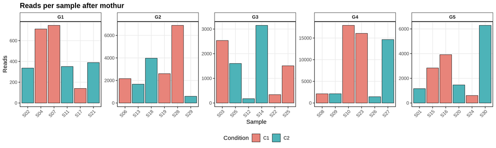

**Figure 1.** Reads per sample after mothur, one panel per study (all five studies, before MetaQC).

**How to read it.** Each bar is one sample and its height is the number of reads left after mothur. Each panel has its own vertical scale, so compare bars within a panel, not across panels. Study G1 has only a few hundred reads per sample while G4 has thousands.

### MetaQC: can the studies be combined?

**Why MetaQC.** A meta-analysis only makes sense if the studies measure comparable things. MetaQC (Kang *et al.*, *Nucleic Acids Research* 2012; R package by Don Kang and George Tseng) gives every study a score on six quality measures and so turns the decision to include or exclude a study into an objective rule. It was written for gene-expression studies; here the “genes” are OTUs and the “pathways” are taxonomic groups (phylum, class, order, family, genus).

- **IQC** (internal quality control): is the co-abundance structure of the study (which OTUs rise and fall together) similar to that of the other studies? This is the homogeneity check.
- **EQC** (external quality control): do OTUs of the same taxonomic group co-vary more than random OTUs?
- **CQCg / CQCp** (consistency quality control): does the study rank OTUs (g) and taxonomic groups (p) by their C1-versus-C2 difference in the same order as the other studies combined?
- **AQCg / AQCp** (accuracy quality control): does the study find the same significant OTUs or groups as the other studies combined?

**How to read a score.** Each score is −log<sub>10</sub>(p-value): higher is better. With K studies a score passes when it is above −log<sub>10</sub>(0.05/K), which is 2.0 for five studies. MetaQC marks scores below that line with an asterisk (*). The *Rank* column is the mean rank of a study over the six measures; lower is better.

**The decision rule used here.** IQC (homogeneity) and CQC (consistency) are the two measures that decide. A study is excluded when it fails both IQC and CQCg; all other studies go on to the diversity analyses, ANCOM-BC and the meta-analysis.

**Keep in mind.** MetaQC was designed for thousands of genes and larger groups. With 10 to 17 OTUs and three samples per condition, the consistency and accuracy measures (CQC, AQC) cannot reach significance in any study, so the decision rests mainly on IQC.

103

Prepare the MetaQC input. For every study, log-ratio transform the counts (CLR) and keep the OTUs seen in at least two of its six samples.

MetaQC expects continuous values, like expression levels. The centred log-ratio (CLR) turns counts into such values and removes the effect of sequencing depth. MetaQC takes a list with one element per study: `x` holds the OTUs in rows and the samples in columns, `y` the condition of each sample.

R code

```
metaqc_input <- lapply(study_data, function(d) {
  present <- d$mat[, colSums(d$mat > 0) > 0, drop = FALSE]
  clr <- log(present + 1)
  clr <- clr - rowMeans(clr)
  keep <- colSums(present > 0) >= 2 & apply(clr, 2, var) > 0
  list(x = t(clr[, keep, drop = FALSE]), y = as.character(d$m$condition))
})
sapply(metaqc_input, function(d) nrow(d$x))
```

Output

```
G1 G2 G3 G4 G5
13 12 10 17 16
```

104

Write the taxonomic groups in the GMT format that MetaQC reads for its pathway-based measures (EQC, CQCp, AQCp).

Each line of a GMT file is one group: its name, a description, then its members. Every phylum, class, order, family and genus with at least two OTUs becomes one group.

R code

```
metaqc_dir <- file.path(out_dir, "metaqc")
dir.create(metaqc_dir, recursive = TRUE, showWarnings = FALSE)
taxon_sets <- unlist(lapply(c("Phylum", "Class", "Order", "Family", "Genus"), function(rank)
  split(rownames(tax_matrix), paste(rank, tax_matrix[, rank], sep = "_"))), recursive = FALSE)
taxon_sets <- taxon_sets[lengths(taxon_sets) >= 2 & !duplicated(taxon_sets)]
writeLines(vapply(names(taxon_sets), function(n) paste(c(n, "taxonomy", taxon_sets[[n]]), collapse = "\t"), character(1)),
           file.path(metaqc_dir, "taxon_sets.gmt"))
lengths(taxon_sets)
```

Output

```
                Phylum_Actinobacteria                     Phylum_Firmicutes                 Phylum_Proteobacteria
                                    9                                    19                                     5
                        Class_Bacilli                      Class_Clostridia               Order_Enterobacteriales
                                    6                                    12                                     4
               Family_Lachnospiraceae                Family_Ruminococcaceae               Family_Streptococcaceae
                                    7                                     5                                     5
                 Genus_Butyricicoccus Genus_Enterobacteriaceae_unclassified                      Genus_Klebsiella
                                    2                                     2                                     2
   Genus_Lachnospiraceae_unclassified    Genus_Ruminococcaceae_unclassified
                                    4                                     2
```

105

Adapt the IQC calculation to small tables.

MetaQC computes IQC by comparing the OTU-by-OTU correlations of every pair of studies. To save memory with thousands of genes it repeats this 100 times on a random 10% of the shared genes. With about ten shared OTUs, 10% is a single OTU and no correlation can be computed, so this function does the same comparison once on all shared OTUs. Everything else in MetaQC is used unchanged.

R code

```
iqc_all_shared <- function(.) {
  pairs <- combn(length(.$.DListF), 2)
  distance <- apply(pairs, 2, function(ii) {
    shared <- intersect(rownames(.$.DListF[[ii[1]]]$x), rownames(.$.DListF[[ii[2]]]$x))
    correlations <- sapply(1:2, function(j) as.vector(as.dist(cor(t(.$.DListF[[ii[j]]]$x[shared, , drop = FALSE])))))
    correlations <- na.omit(correlations)
    (1 - cor(correlations[, 1], correlations[, 2], method = "spearman")) / 2
  })
  m <- matrix(0, length(.$.DListF), length(.$.DListF), dimnames = list(names(.$.DListF), names(.$.DListF)))
  m[t(pairs)] <- distance
  m[t(pairs[2:1, ])] <- distance
  .$.DistOfStudies <- as.dist(m)
}
```

106

Run MetaQC: create the MetaQC object, plug in the IQC function and compute all six measures with 10,000 permutations.

MetaQC writes helper files in the working directory, so the run happens inside the `metaqc` output folder and R returns to the workshop folder afterwards. `registerDoSEQ()` tells MetaQC to run on one core.

R code

```
foreach::registerDoSEQ()
run_metaqc <- function() {
  old_dir <- setwd(metaqc_dir)
  on.exit(setwd(old_dir))
  set.seed(20261114)
  object <- MetaQC(metaqc_input, "taxon_sets.gmt", filterGenes = FALSE, minNumGenes = 2, verbose = FALSE)
  object$.CalcDistOfStudies <- iqc_all_shared
  suppressWarnings(runQC(object, B = 1e4, fileForCQCp = "taxon_sets.gmt"))
  object
}
metaqc <- run_metaqc()
metaqc$Print()
```

Output

```
Number of Studies:  5

Dimension of Each Study:
        G1 G2 G3 G4 G5
Genes   13 12 10 17 16
Samples  6  6  6  6  6

Quality Control Result:
  Study   IQC   EQC  CQCg  CQCp AQCg AQCp Rank
1    G3  8.06 0.32* 0.29* 0.87*   0*   0* 2.33
2    G1  2.56  0.4* 0.13* 0.86*   0*   0* 2.67
3    G2  4.91 0.34* 0.08* 0.53*   0*   0* 3.00
4    G4 1.56* 0.86* 0.06* 0.12*   0*   0* 3.50
5    G5   2.3 1.14* 0.02* 0.01*   0*   0* 3.50
```

107

Print how different the studies are from each other (the IQC distances).

0 means two studies have the same co-abundance structure; 0.5 means no relation. A study whose distances to the others are larger than the distances among the others gets a low IQC score.

R code

```
round(metaqc$.DistOfStudies, 2)
```

Output

```
     G1   G2   G3   G4
G2 0.38
G3 0.28 0.34
G4 0.45 0.36 0.37
G5 0.43 0.36 0.35 0.50
```

108

Draw the six MetaQC scores of every study with the pass line.

R code

```
metaqc_threshold <- -log10(0.05 / length(studies))
metaqc_scores <- metaqc$.Scores
metaqc_long <- data.frame(study = rep(rownames(metaqc_scores), ncol(metaqc_scores)),
                          measure = factor(rep(colnames(metaqc_scores), each = nrow(metaqc_scores)), levels = colnames(metaqc_scores)),
                          score = unlist(metaqc_scores))
metaqc_long$result <- ifelse(metaqc_long$score >= metaqc_threshold, "Passes", "Does not pass")
write.csv(cbind(study = rownames(metaqc_scores), round(metaqc_scores, 3)), file.path(out_dir, "metaqc_scores.csv"), row.names = FALSE)
metaqc_plot <- ggplot(metaqc_long, aes(study, score, fill = result)) +
  geom_col(colour = "black", linewidth = 0.3, width = 0.7) +
  geom_hline(yintercept = metaqc_threshold, linetype = "dashed") +
  geom_text(aes(label = sprintf("%.2f", pmax(score, 0))), vjust = -0.4, size = 3) +
  facet_wrap(~measure, nrow = 1) +
  scale_fill_manual(values = c("Passes" = condition_colours[["C2"]], "Does not pass" = not_significant_colour)) +
  scale_y_continuous(expand = expansion(mult = c(0, 0.12))) +
  labs(title = "MetaQC quality scores per study", subtitle = sprintf("Score = -log10(p); dashed line = -log10(0.05/%d) = %.1f", length(studies), metaqc_threshold),
       x = "Study", y = "Score", fill = NULL)
ggsave(file.path(out_dir, "metaqc_scores.png"), metaqc_plot, width = 14, height = 4.6, dpi = 180)
print(metaqc_plot)
```

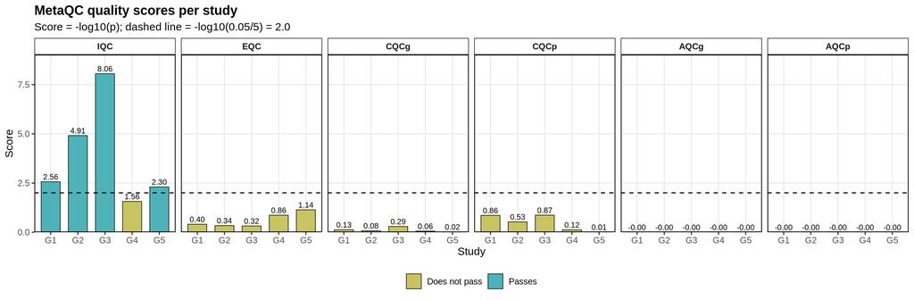

**Figure 2.** MetaQC scores of the five studies on the six quality measures.

**How to read it.** Each bar is −log<sub>10</sub>(p) of one measure for one study; higher is better and the dashed line (2.0 for five studies) is the pass mark. On IQC four studies pass: G3 (8.06), G2 (4.91), G1 (2.56) and G5 (2.30). G4 does not (1.56): its co-abundance structure differs most from the others, and the IQC distance between G4 and G5 (0.50) is the largest of all pairs. No study passes EQC, CQC or AQC, which is expected with 10 to 17 OTUs and three samples per condition. G4 fails both IQC and CQCg and is therefore excluded; G1, G2, G3 and G5 go on to the next steps.

109

Apply the decision rule: exclude a study that fails both IQC and CQCg, and keep the others for every later step.

From here on, `studies` and `study_data` hold only the included studies, so the alpha and beta diversity, ANCOM-BC and the meta-analysis all use the quality-controlled set.

R code

```
metaqc_decision <- data.frame(study = rownames(metaqc_scores), IQC = round(metaqc_scores$IQC, 2), CQCg = round(metaqc_scores$CQCg, 2),
                              passes_IQC = metaqc_scores$IQC >= metaqc_threshold, passes_CQCg = metaqc_scores$CQCg >= metaqc_threshold)
metaqc_decision$included <- metaqc_decision$passes_IQC | metaqc_decision$passes_CQCg
metaqc_decision <- metaqc_decision[order(metaqc_decision$study), ]
write.csv(metaqc_decision, file.path(out_dir, "metaqc_decision.csv"), row.names = FALSE)
print(metaqc_decision, row.names = FALSE)
excluded_studies <- metaqc_decision$study[!metaqc_decision$included]
studies <- setdiff(studies, excluded_studies)
study_data <- study_data[studies]
studies
```

Output

```
 study  IQC CQCg passes_IQC passes_CQCg included
    G1 2.56 0.13       TRUE       FALSE     TRUE
    G2 4.91 0.08       TRUE       FALSE     TRUE
    G3 8.06 0.29       TRUE       FALSE     TRUE
    G4 1.56 0.06      FALSE       FALSE    FALSE
    G5 2.30 0.02       TRUE       FALSE     TRUE
[1] "G1" "G2" "G3" "G5"
```

### Alpha diversity: Observed, Chao1, Shannon and Inverse Simpson

**What it measures.** Diversity *within* one sample.

- **Observed**: how many different OTUs are present (richness).
- **Chao1**: an estimate of the true richness. It adds to the observed count an estimate of the OTUs that were missed, based on how many OTUs were seen only once or twice. If no OTU is seen only once, Chao1 equals Observed.
- **Shannon**: richness and evenness together.
- **Inverse Simpson**: the effective number of dominant OTUs; it gives more weight to the abundant ones.

**Keep in mind.** With three samples per condition, an exact two-sided test cannot give a p-value below 0.1.

110

Calculate the four alpha-diversity indices for every sample.

`estimateR()` from vegan returns Chao1 in its row `S.chao1`; `diversity()` returns Shannon and Inverse Simpson.

R code

```
alpha <- do.call(rbind, lapply(studies, function(s) {
  d <- study_data[[s]]
  data.frame(study = s, sample_name = rownames(d$mat), condition = d$m$condition,
             observed = rowSums(d$mat > 0),
             chao1 = estimateR(d$mat)["S.chao1", ],
             shannon = diversity(d$mat, "shannon"),
             inverse_simpson = diversity(d$mat, "invsimpson"))
}))
write.csv(alpha, file.path(out_dir, "alpha_by_study.csv"), row.names = FALSE)
print(alpha, row.names = FALSE, digits = 3)
```

Output

```
 study sample_name condition observed chao1 shannon inverse_simpson
    G1         S04        C1       10  10.0  1.8069            4.77
    G1         S07        C1       10  10.0  1.6439            3.80
    G1         S17        C1        9   9.5  1.7677            5.09
    G1         S02        C2        8  14.0  0.4280            1.22
    G1         S11        C2        7   7.0  1.6908            4.93
    G1         S21        C2        8   8.0  1.5687            3.84
    G2         S06        C1        9   9.0  1.3857            3.39
    G2         S19        C1       11  12.5  1.0793            2.38
    G2         S28        C1       10  10.0  1.5524            4.00
    G2         S13        C2        7   7.0  0.6127            1.33
    G2         S18        C2       10  10.0  0.9306            1.71
    G2         S29        C2       11  13.0  1.0071            2.05
    G3         S03        C1        8   8.0  1.3987            3.57
    G3         S22        C1        4   4.0  0.9571            2.25
    G3         S25        C1        9   9.0  1.6630            4.40
    G3         S05        C2        8   8.0  1.3430            3.10
    G3         S12        C2        7   7.0  1.5930            3.98
    G3         S14        C2        8   8.0  0.8929            1.81
    G5         S15        C1        4   4.0  0.0788            1.03
    G5         S16        C1       10  10.5  0.7499            1.52
    G5         S24        C1       24  51.5  1.8151            3.75
    G5         S01        C2       14  14.0  1.2686            2.05
    G5         S20        C2       13  14.0  1.3407            2.55
    G5         S30        C2       23  37.0  0.9586            1.76
```

111

Write the exact permutation test: compare the observed C2-minus-C1 difference with all 20 ways of splitting six samples into two groups of three.

R code

```
allocations <- combn(6, 3)
exact_test <- function(x) {
  observed <- mean(x[4:6]) - mean(x[1:3])
  permuted <- apply(allocations, 2, function(i) mean(x[-i]) - mean(x[i]))
  c(difference = observed, p = mean(abs(permuted) >= abs(observed) - 1e-12))
}
```

112

Test every index in every study and adjust the p-values within each study.

R code

```
alpha_metrics <- c(observed = "Observed OTUs", chao1 = "Chao1 richness", shannon = "Shannon", inverse_simpson = "Inverse Simpson")
alpha_tests <- do.call(rbind, lapply(studies, function(s) do.call(rbind, lapply(names(alpha_metrics), function(metric) {
  r <- exact_test(alpha[alpha$study == s, metric])
  data.frame(study = s, metric = metric, difference_C2_minus_C1 = r[["difference"]], p_value = r[["p"]])
}))))
alpha_tests$adjusted_p <- ave(alpha_tests$p_value, alpha_tests$study, FUN = function(p) p.adjust(p, "BH"))
write.csv(alpha_tests, file.path(out_dir, "alpha_tests_by_study.csv"), row.names = FALSE)
print(alpha_tests, row.names = FALSE, digits = 3)
```

Output

```
 study          metric difference_C2_minus_C1 p_value adjusted_p
    G1        observed                -2.0000     0.1      0.400
    G1           chao1                -0.1667     1.0      1.000
    G1         shannon                -0.5104     0.2      0.400
    G1 inverse_simpson                -1.2240     0.5      0.667
    G2        observed                -0.6667     0.9      1.000
    G2           chao1                -0.5000     1.0      1.000
    G2         shannon                -0.4890     0.1      0.200
    G2 inverse_simpson                -1.5571     0.1      0.200
    G3        observed                 0.6667     1.0      1.000
    G3           chao1                 0.6667     1.0      1.000
    G3         shannon                -0.0633     0.7      1.000
    G3 inverse_simpson                -0.4407     0.6      1.000
    G5        observed                 4.0000     0.6      1.000
    G5           chao1                -0.3333     1.0      1.000
    G5         shannon                 0.3081     0.6      1.000
    G5 inverse_simpson                 0.0166     1.0      1.000
```

113

Draw the four indices as violin plots: studies along the x-axis, the two conditions next to each other, and the exact p-value above each study.

Each violin has a small box plot inside and the three samples as dots, as in the reference paper. With three samples the violin shape is only a smoothed sketch of where the values lie.

R code

```
alpha_long <- do.call(rbind, lapply(names(alpha_metrics), function(metric)
  data.frame(alpha[, c("study", "sample_name", "condition")], metric = alpha_metrics[[metric]], value = alpha[[metric]])))
alpha_long$metric <- factor(alpha_long$metric, levels = alpha_metrics)
alpha_labels <- do.call(rbind, lapply(names(alpha_metrics), function(metric) {
  top <- aggregate(value ~ study, alpha_long[alpha_long$metric == alpha_metrics[[metric]], ], max)
  tests <- alpha_tests[alpha_tests$metric == metric, ]
  data.frame(study = top$study, metric = alpha_metrics[[metric]], value = top$value,
             label = sprintf("p = %.1f", tests$p_value[match(top$study, tests$study)]))
}))
alpha_labels$metric <- factor(alpha_labels$metric, levels = alpha_metrics)
alpha_plot <- ggplot(alpha_long, aes(study, value, fill = condition)) +
  geom_violin(trim = TRUE, scale = "width", width = 0.7, colour = "black", linewidth = 0.4, position = position_dodge(0.8)) +
  geom_boxplot(width = 0.12, colour = "black", linewidth = 0.3, outlier.shape = NA, position = position_dodge(0.8), show.legend = FALSE) +
  geom_point(shape = 21, size = 1.6, colour = "black", position = position_dodge(0.8), show.legend = FALSE) +
  geom_text(data = alpha_labels, aes(study, Inf, label = label), inherit.aes = FALSE, vjust = 1.6, size = 3.2) +
  facet_wrap(~metric, nrow = 2, scales = "free_y") +
  scale_fill_manual(values = condition_colours) +
  scale_y_continuous(expand = expansion(mult = c(0.05, 0.14))) +
  labs(title = "Alpha diversity by study and condition", x = "Study", y = "Index value", fill = "Condition")
ggsave(file.path(out_dir, "alpha_by_study.png"), alpha_plot, width = 12, height = 8, dpi = 180)
print(alpha_plot)
```

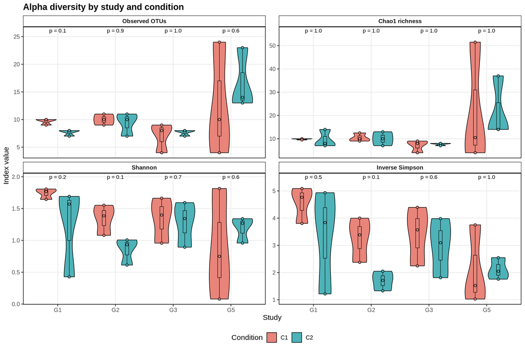

**Figure 3.** Violin plots of Observed OTUs, Chao1, Shannon and Inverse Simpson in the four included studies, with the exact permutation p-value above each study.

**How to read it.** Each violin is the three samples of one condition in one study; the box inside marks the median and the dots are the samples. With three samples the violin shape is only a smoothed sketch, so read the dots. The direction of the difference is not the same in every study, and no comparison reaches p < 0.05; the smallest possible value is 0.1. Chao1 is close to the observed count in most samples because few OTUs were seen only once; the clearest exception is G5, where two samples have several single-read OTUs.

### Beta diversity: Bray–Curtis, Canberra, Jclass and ThetaYC

**What it measures.** How different two samples are from each other. Four distances are used, the same calculators that mothur offers in `dist.shared`:

- **Bray–Curtis**: based on abundances; dominated by the common OTUs.
- **Canberra**: based on abundances, but every OTU counts equally, so rare OTUs matter as much as common ones.
- **Jclass** (Jaccard): uses only presence or absence. It answers “do the two samples contain the same OTUs?”
- **ThetaYC** (Yue & Clayton): compares the community *structure*, that is the proportions of shared and unshared OTUs.

**PCoA.** Each distance matrix is turned into a map in which similar samples sit close together. The percentage on each axis is the share of the total variation that the axis shows.

114

Write the ThetaYC distance, which vegan does not include.

For two samples with relative abundances a and b: 1 − Σab / (Σa² + Σb² − Σab).

R code

```
thetayc <- function(relative) {
  cross <- relative %*% t(relative)
  squares <- diag(cross)
  as.dist(1 - cross / (outer(squares, squares, "+") - cross))
}
```

115

List the four distances. Each entry is a small function that takes one study and returns its distance matrix.

R code

```
distance_functions <- list(
  "Bray-Curtis" = function(d) vegdist(d$relative, method = "bray"),
  "Canberra"    = function(d) vegdist(d$relative, method = "canberra"),
  "Jclass"      = function(d) vegdist(d$mat, method = "jaccard", binary = TRUE),
  "ThetaYC"     = function(d) thetayc(d$relative))
```

116

For every distance and every study: run the PCoA, the PERMANOVA and the PERMDISP test.

`cmdscale()` is the PCoA; its eigenvalues give the percentage of variation on each axis. `adonis2()` is PERMANOVA, and `betadisper()` with `permutest()` is PERMDISP. Both ask for 999 permutations, but with six samples there are only 720 possible orderings, so vegan tries every one of them and the tests are exact; `suppressMessages()` hides the note that says so. It is written `vegan::permutest()` because the metafor package has a function with the same name. `suppressWarnings()` hides a harmless note that vegan prints for distances that cannot be drawn exactly on flat axes.

R code

```
beta <- lapply(names(distance_functions), function(distance_name) lapply(studies, function(s) {
  d <- study_data[[s]]
  distance <- distance_functions[[distance_name]](d)
  pcoa <- cmdscale(distance, k = 2, eig = TRUE)
  explained <- 100 * pcoa$eig[1:2] / sum(pcoa$eig[pcoa$eig > 0])
  permanova <- suppressMessages(adonis2(distance ~ condition, data = d$m, permutations = 999))
  permdisp <- suppressMessages(vegan::permutest(suppressWarnings(betadisper(distance, d$m$condition)), permutations = 999))
  list(points = data.frame(distance = distance_name, study = s, sample_name = rownames(d$m), condition = d$m$condition,
                           PCoA1 = pcoa$points[, 1], PCoA2 = pcoa$points[, 2]),
       tests = data.frame(distance = distance_name, study = s, axis1_percent = explained[1], axis2_percent = explained[2],
                          R2 = permanova$R2[1], F = permanova$F[1], permanova_p = permanova$`Pr(>F)`[1],
                          permdisp_p = permdisp$tab$`Pr(>F)`[1]))
}))
pcoa_points <- do.call(rbind, lapply(beta, function(x) do.call(rbind, lapply(x, `[[`, "points"))))
beta_tests <- do.call(rbind, lapply(beta, function(x) do.call(rbind, lapply(x, `[[`, "tests"))))
write.csv(pcoa_points, file.path(out_dir, "pcoa_by_study.csv"), row.names = FALSE)
write.csv(beta_tests, file.path(out_dir, "permanova_by_study.csv"), row.names = FALSE)
```

117

Print the PERMANOVA and PERMDISP results with the percentage of variation on the two PCoA axes.

R code

```
print(beta_tests, row.names = FALSE, digits = 3)
```

Output

```
    distance study axis1_percent axis2_percent     R2     F permanova_p permdisp_p
 Bray-Curtis    G1          40.0          29.0 0.2173 1.111         0.5      0.801
 Bray-Curtis    G2          49.8          33.2 0.3070 1.772         0.2      0.701
 Bray-Curtis    G3          55.0          29.7 0.2800 1.556         0.3      0.801
 Bray-Curtis    G5          69.6          22.4 0.0724 0.312         0.9      0.701
    Canberra    G1          29.9          22.2 0.1920 0.951         0.5      0.501
    Canberra    G2          28.2          25.8 0.2072 1.045         0.5      0.601
    Canberra    G3          36.4          27.6 0.1796 0.876         0.6      0.701
    Canberra    G5          32.0          23.3 0.2134 1.085         0.5      0.601
      Jclass    G1          44.7          27.5 0.1825 0.893         0.7      0.401
      Jclass    G2          39.1          37.1 0.1629 0.778         0.6      0.101
      Jclass    G3          53.9          39.4 0.2350 1.229         0.3      0.401
      Jclass    G5          53.5          27.1 0.2141 1.090         0.4      0.201
     ThetaYC    G1          38.5          27.9 0.2206 1.132         0.4      0.401
     ThetaYC    G2          51.5          36.4 0.2991 1.707         0.2      0.601
     ThetaYC    G3          51.9          26.8 0.2661 1.450         0.2      0.601
     ThetaYC    G5          75.1          23.6 0.0436 0.182         1.0      0.701
```

118

Write a function that returns the outline of an ellipse around the samples of one condition.

The ellipse is centred on the mean of the samples and follows their spread (their covariance); it covers about 68% of a normal distribution fitted to them. `stat_ellipse()` from ggplot2 needs at least four samples per group, so with three the ellipse is calculated here.

R code

```
ellipse_points <- function(points, level = 0.68) {
  xy <- as.matrix(points[, c("PCoA1", "PCoA2")])
  spread <- eigen(cov(xy), symmetric = TRUE)
  circle <- rbind(cos(seq(0, 2 * pi, length.out = 100)), sin(seq(0, 2 * pi, length.out = 100)))
  outline <- t(colMeans(xy) + spread$vectors %*% (sqrt(pmax(spread$values, 0) * qchisq(level, 2)) * circle))
  data.frame(condition = points$condition[1], PCoA1 = outline[, 1], PCoA2 = outline[, 2])
}
```

119

Write a function that draws the PCoA of one distance, one panel per study, with the percentage of variation written on the x- and y-axis.

An ellipse is drawn around the samples of each condition. Every panel is its own ordination, so each has its own axis labels.

R code

```
pcoa_figure <- function(distance_name) {
  panels <- lapply(studies, function(s) {
    points <- pcoa_points[pcoa_points$distance == distance_name & pcoa_points$study == s, ]
    tests <- beta_tests[beta_tests$distance == distance_name & beta_tests$study == s, ]
    ellipses <- do.call(rbind, lapply(split(points, points$condition), ellipse_points))
    ggplot(points, aes(PCoA1, PCoA2, colour = condition, fill = condition)) +
      geom_hline(yintercept = 0, colour = "grey80") + geom_vline(xintercept = 0, colour = "grey80") +
      geom_polygon(data = ellipses, alpha = 0.2, linewidth = 0.5) +
      geom_point(size = 3) +
      geom_text(aes(label = sample_name), vjust = -1, size = 3, show.legend = FALSE) +
      scale_fill_manual(values = condition_colours) +
      scale_colour_manual(values = condition_colours) +
      scale_x_continuous(expand = expansion(mult = 0.2)) + scale_y_continuous(expand = expansion(mult = 0.2)) +
      labs(title = s,
           subtitle = sprintf("PERMANOVA R2 = %.2f, p = %.2f\nPERMDISP p = %.2f", tests$R2, tests$permanova_p, tests$permdisp_p),
           x = sprintf("PCoA1 (%.1f%%)", tests$axis1_percent), y = sprintf("PCoA2 (%.1f%%)", tests$axis2_percent),
           colour = "Condition", fill = "Condition") +
      theme(plot.subtitle = element_text(size = 8.5), panel.grid = element_blank())
  })
  wrap_plots(panels, nrow = 1, guides = "collect") +
    plot_annotation(title = paste(distance_name, "PCoA")) & theme(legend.position = "bottom")
}
```

120

Draw and save the Bray–Curtis PCoA.

R code

```
pcoa_bray <- pcoa_figure("Bray-Curtis")
ggsave(file.path(out_dir, "pcoa_braycurtis_by_study.png"), pcoa_bray, width = 17, height = 4.8, dpi = 180)
print(pcoa_bray)
```

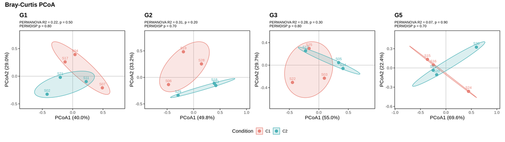

**Figure 4.** Bray–Curtis PCoA with an ellipse per condition, one panel per included study. The x- and y-axis labels give the percentage of variation shown by each axis.

**How to read it.** Each dot is a sample and each ellipse outlines the three samples of one condition. Ellipses that overlap mean the conditions are not separated; a long thin ellipse means the three samples lie almost on a line. The two axes together show 69% to 92% of the variation. Each panel is a separate ordination, so positions cannot be compared between panels. Condition explains 22% (G1), 31% (G2), 28% (G3) and 7% (G5) of the variation; none is significant.

121

Draw and save the Canberra PCoA.

R code

```
pcoa_canberra <- pcoa_figure("Canberra")
ggsave(file.path(out_dir, "pcoa_canberra_by_study.png"), pcoa_canberra, width = 17, height = 4.8, dpi = 180)
print(pcoa_canberra)
```

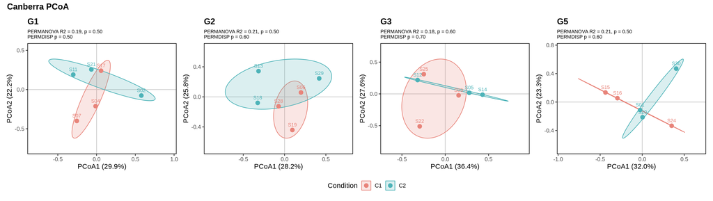

**Figure 5.** Canberra PCoA with an ellipse per condition, one panel per included study.

**How to read it.** Canberra gives rare OTUs the same weight as common ones. The axes show less of the variation here (52% to 64% for the two axes together), which is usual when many rare OTUs each add a little. Condition explains 18% to 21% in every study; none is significant.

122

Draw and save the Jclass PCoA.

R code

```
pcoa_jclass <- pcoa_figure("Jclass")
ggsave(file.path(out_dir, "pcoa_jclass_by_study.png"), pcoa_jclass, width = 17, height = 4.8, dpi = 180)
print(pcoa_jclass)
```

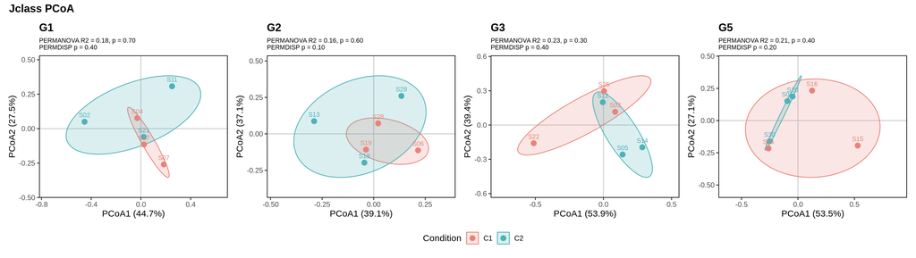

**Figure 6.** Jclass (presence or absence) PCoA with an ellipse per condition, one panel per included study.

**How to read it.** Only which OTUs are present matters here, not how abundant they are. Samples that share the same OTUs fall close together. Condition explains 16% to 24%; none is significant.

123

Draw and save the ThetaYC PCoA.

R code

```
pcoa_thetayc <- pcoa_figure("ThetaYC")
ggsave(file.path(out_dir, "pcoa_thetayc_by_study.png"), pcoa_thetayc, width = 17, height = 4.8, dpi = 180)
print(pcoa_thetayc)
```

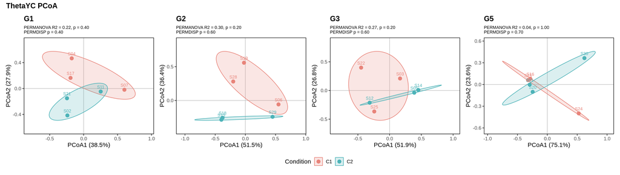

**Figure 7.** ThetaYC PCoA with an ellipse per condition, one panel per included study.

**How to read it.** ThetaYC compares community structure and, like Bray–Curtis, is driven by the abundant OTUs, so the two maps look alike. Condition explains 22% (G1), 30% (G2), 27% (G3) and 4% (G5); none is significant.

124

Summarise PERMANOVA in one picture: the share of variation explained by condition (R²) for every distance and study, with the p-value underneath.

R code

```
beta_tests$distance <- factor(beta_tests$distance, levels = rev(names(distance_functions)))
permanova_plot <- ggplot(beta_tests, aes(study, distance, fill = R2)) +
  geom_tile(colour = "black") +
  geom_text(aes(label = sprintf("R2 = %.2f\np = %.2f", R2, permanova_p)), size = 3.4) +
  scale_fill_gradient(low = "white", high = condition_colours[["C2"]], limits = c(0, 1)) +
  labs(title = "PERMANOVA: variation explained by condition", x = "Study", y = NULL, fill = "R2") +
  theme(panel.grid = element_blank(), legend.position = "right")
ggsave(file.path(out_dir, "permanova_by_study.png"), permanova_plot, width = 9, height = 3.8, dpi = 180)
print(permanova_plot)
```

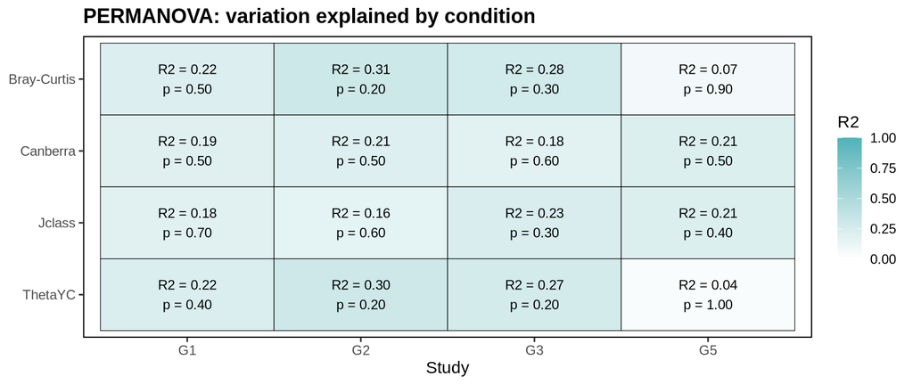

**Figure 8.** PERMANOVA R² and p-value for every distance and included study.

**How to read it.** Read along a row to compare studies and down a column to compare distances. A darker tile means the condition explains more of the variation. The abundance-based distances (Bray–Curtis and ThetaYC) agree with each other, and so do the two that give weight to rare OTUs (Canberra and Jclass). No p-value is below 0.05 with any distance, and no PERMDISP test is significant either.

### ANCOM-BC per study: effect size and standard error for every OTU

**One study at a time.** ANCOM-BC is run separately in each included study, never on a merged table, so that differences between studies (sequencing depth, filtering) cannot create false differences between conditions. From every study we keep, for each OTU, the effect size (log fold change) and its standard error (SE): exactly the two numbers the meta-analysis needs.

**Why ANCOM-BC instead of LEfSe.** LEfSe first needs a Kruskal–Wallis p-value below 0.05. With three samples per condition the smallest value that test can give is 0.0495, and after adjustment for multiple testing nothing passes, so LEfSe reported no OTU in any study whatever the LDA cut-off. LEfSe also gives a score without a standard error, which a meta-analysis cannot use.

**What ANCOM-BC does.** Sequencing gives relative abundances: if one OTU goes up, the others must appear to go down even if they did not change. ANCOM-BC estimates and removes this bias, then reports for each OTU its *effect size*, the log fold change between conditions, together with a standard error, a p-value and an adjusted p-value (q). The function used is `ancombc2()`, the current version in the ANCOMBC package; the reference paper also used ANCOM-BC.

**How to read a value.** A log fold change of 0 means no difference; +0.69 means about twice as abundant in C2; −0.69 means about half.

125

Run ANCOM-BC in every study and collect, for every OTU, the effect size (log fold change, C2 versus C1), its standard error, the p-value and the adjusted p-value.

OTUs seen in fewer than two samples of a study are left out before the model is fitted. ANCOM-BC returns no estimate (NA) for an OTU found in only one condition, and a p-value of exactly 1 for an OTU found in a single sample of each condition, because it cannot be tested. The column `usable` marks the estimates that can be trusted and carried forward.

R code

```
ancom <- do.call(rbind, lapply(studies, function(s) {
  d <- study_data[[s]]
  keep <- colSums(d$mat > 0) >= 2
  set.seed(20261114)
  fit <- suppressWarnings(suppressMessages(ancombc2(data = t(d$mat[, keep, drop = FALSE]), taxa_are_rows = TRUE,
           meta_data = d$m, fix_formula = "condition", group = "condition", p_adj_method = "BH",
           prv_cut = 0, lib_cut = 0, struc_zero = FALSE, pseudo_sens = FALSE, verbose = FALSE)))
  r <- fit$res
  data.frame(study = s, feature = r$taxon, lfc_C2_vs_C1 = r$lfc_conditionC2, se = r$se_conditionC2,
             W = r$W_conditionC2, p_value = r$p_conditionC2, q_value = r$q_conditionC2)
}))
ancom$taxon <- unname(taxon_label[ancom$feature])
ancom$usable <- is.finite(ancom$lfc_C2_vs_C1) & is.finite(ancom$se) & ancom$se > 0 & ancom$p_value < 1
```

126

Label each estimate: higher in C1, higher in C2, or not significant.

The label uses the unadjusted p-value, because with three samples per condition almost nothing can pass the adjusted threshold. The adjusted value (q) is kept in the table and shown in the figures.

R code

```
significance_level <- 0.05
ancom$direction <- ifelse(!ancom$usable | ancom$p_value >= significance_level, "Not significant",
                          ifelse(ancom$lfc_C2_vs_C1 > 0, "Higher in C2", "Higher in C1"))
ancom$direction <- factor(ancom$direction, levels = c("Higher in C1", "Higher in C2", "Not significant"))
direction_colours <- c("Higher in C1" = condition_colours[["C1"]], "Higher in C2" = condition_colours[["C2"]], "Not significant" = not_significant_colour)
write.csv(ancom, file.path(out_dir, "ancombc_by_study.csv"), row.names = FALSE)
```

127

Print the effect size of every OTU in every study.

R code

```
print(ancom[, c("study", "taxon", "lfc_C2_vs_C1", "se", "p_value", "q_value", "usable", "direction")], row.names = FALSE, digits = 3)
```

**Output: 52 lines. Show**

```
 study                               taxon lfc_C2_vs_C1    se p_value q_value usable       direction
    G1                     Otu01 Dialister     -3.71238 0.526  1.0000   1.000  FALSE Not significant
    G1               Otu02 Bifidobacterium      1.24545 1.189  0.3539   1.000   TRUE Not significant
    G1                    Otu03 Klebsiella     -0.49371 0.898  0.6376   1.000   TRUE Not significant
    G1  Otu04 Lachnospiraceae_unclassified      0.24225 1.244  0.8636   1.000   TRUE Not significant
    G1 Otu05 Lachnospiracea_incertae_sedis     -0.80914 1.449  0.6155   1.000   TRUE Not significant
    G1               Otu06 Bifidobacterium     -0.52868 1.205  0.6836   1.000   TRUE Not significant
    G1                Otu07 Clostridium_IV           NA    NA  1.0000   1.000  FALSE Not significant
    G1                Otu08 Butyricicoccus     -0.67938 0.763  0.4233   1.000   TRUE Not significant
    G1                   Otu09 Coprococcus           NA    NA  1.0000   1.000  FALSE Not significant
    G1                   Otu10 Haemophilus      0.44222 1.240  0.7449   1.000   TRUE Not significant
    G1  Otu13 Ruminococcaceae_unclassified     -0.02180 0.520  0.9733   1.000   TRUE Not significant
    G1  Otu14 Lachnospiraceae_unclassified           NA    NA  1.0000   1.000  FALSE Not significant
    G1                 Otu16 Streptococcus     -2.16524 0.526  1.0000   1.000  FALSE Not significant
    G2                     Otu01 Dialister      0.26718 2.112  0.9109   1.000   TRUE Not significant
    G2               Otu02 Bifidobacterium      1.59209 0.938  0.3389   0.660   TRUE Not significant
    G2  Otu04 Lachnospiraceae_unclassified      1.54385 0.989  0.2165   0.660   TRUE Not significant
    G2 Otu05 Lachnospiracea_incertae_sedis     -2.75266 1.052  0.0793   0.476   TRUE Not significant
    G2               Otu06 Bifidobacterium      2.58242 1.831  0.2312   0.660   TRUE Not significant
    G2                Otu07 Clostridium_IV      0.19429 1.658  0.9141   1.000   TRUE Not significant
    G2                Otu08 Butyricicoccus      0.26225 1.581  0.8763   1.000   TRUE Not significant
    G2                   Otu09 Coprococcus      3.39901 1.407  0.0730   0.476   TRUE Not significant
    G2                   Otu10 Haemophilus      0.09241 1.594  0.9574   1.000   TRUE Not significant
    G2  Otu13 Ruminococcaceae_unclassified     -0.00823 0.742  1.0000   1.000  FALSE Not significant
    G2  Otu14 Lachnospiraceae_unclassified     -1.20163 0.925  0.3236   0.660   TRUE Not significant
    G2                 Otu16 Streptococcus      1.01726 1.002  0.3847   0.660   TRUE Not significant
    G3               Otu02 Bifidobacterium      0.91756 1.274  0.5234   0.898   TRUE Not significant
    G3  Otu04 Lachnospiraceae_unclassified      1.52157 1.329  0.3354   0.898   TRUE Not significant
    G3 Otu05 Lachnospiracea_incertae_sedis     -2.40070 0.876  0.1114   0.669   TRUE Not significant
    G3               Otu06 Bifidobacterium      0.57147 0.852  0.5389   0.898   TRUE Not significant
    G3                Otu08 Butyricicoccus     -0.91702 1.117  0.4577   0.898   TRUE Not significant
    G3                   Otu10 Haemophilus     -0.07793 1.079  0.9541   1.000   TRUE Not significant
    G3               Otu11 Bifidobacterium     -0.21840 0.444  0.7089   1.000   TRUE Not significant
    G3                 Otu15 Lactobacillus           NA    NA  1.0000   1.000  FALSE Not significant
    G3                 Otu16 Streptococcus      1.11413 0.546  0.1338   0.669   TRUE Not significant
    G3  Otu17 Lachnospiraceae_unclassified      0.20779 0.462  1.0000   1.000  FALSE Not significant
    G5                     Otu01 Dialister      1.05579 0.544  0.3029   0.808   TRUE Not significant
    G5               Otu02 Bifidobacterium     -1.16995 2.199  0.6316   0.974   TRUE Not significant
    G5                    Otu03 Klebsiella     -0.14141 1.730  0.9388   1.000   TRUE Not significant
    G5  Otu04 Lachnospiraceae_unclassified      0.89857 1.395  0.5654   0.974   TRUE Not significant
    G5 Otu05 Lachnospiracea_incertae_sedis      1.02242 1.441  0.5293   0.974   TRUE Not significant
    G5               Otu06 Bifidobacterium      1.97356 1.235  0.1854   0.597   TRUE Not significant
    G5                Otu08 Butyricicoccus     -2.01189 1.179  0.1866   0.597   TRUE Not significant
    G5                   Otu09 Coprococcus     -0.72880 0.682  0.3971   0.908   TRUE Not significant
    G5                   Otu10 Haemophilus     -0.62862 1.557  0.7134   0.974   TRUE Not significant
    G5               Otu12 Parabacteroides      0.36076 0.977  0.7306   0.974   TRUE Not significant
    G5  Otu13 Ruminococcaceae_unclassified      3.61873 0.614  0.0276   0.442   TRUE    Higher in C2
    G5  Otu14 Lachnospiraceae_unclassified     -0.09120 0.614  0.9062   1.000   TRUE Not significant
    G5                 Otu15 Lactobacillus      3.72195 1.157  0.0845   0.597   TRUE Not significant
    G5                 Otu16 Streptococcus      2.04405 1.246  0.1761   0.597   TRUE Not significant
    G5              Otu21 Clostridium_XlVa     -0.73455 0.562  1.0000   1.000  FALSE Not significant
    G5                 Otu24 Streptococcus     -0.04141 0.562  1.0000   1.000  FALSE Not significant
```

128

Count the estimates and how many are significant.

R code

```
table(study = ancom$study, result = ancom$direction)
c(estimates = nrow(ancom), usable = sum(ancom$usable), p_below_0.05 = sum(ancom$usable & ancom$p_value < 0.05), q_below_0.05 = sum(ancom$usable & ancom$q_value < 0.05))
```

Output

```
     result
study Higher in C1 Higher in C2 Not significant
   G1            0            0              13
   G2            0            0              12
   G3            0            0              10
   G5            0            1              15
   estimates       usable p_below_0.05 q_below_0.05
          51           41            1            0
```

129

Draw the effect size of every OTU with its 95% confidence interval, one panel per study.

R code

```
ancom_drawn <- ancom[ancom$usable, ]
ancom_plot <- ggplot(ancom_drawn, aes(lfc_C2_vs_C1, reorder(paste(study, taxon, sep = "|"), lfc_C2_vs_C1), fill = direction)) +
  geom_vline(xintercept = 0, colour = "grey40") +
  geom_errorbar(aes(xmin = lfc_C2_vs_C1 - 1.96 * se, xmax = lfc_C2_vs_C1 + 1.96 * se), width = 0, orientation = "y") +
  geom_point(shape = 21, size = 3, colour = "black") +
  facet_wrap(~study, nrow = 1, scales = "free_y") +
  scale_y_discrete(labels = function(x) sub("^[^|]*\\|", "", x)) +
  scale_fill_manual(values = direction_colours, drop = FALSE) +
  labs(title = "ANCOM-BC effect sizes: C2 versus C1", x = "Log fold change (natural log), with 95% confidence interval", y = NULL, fill = NULL) +
  theme(axis.text.y = element_text(size = 7))
ggsave(file.path(out_dir, "ancombc_by_study.png"), ancom_plot, width = 18, height = 5.6, dpi = 180)
print(ancom_plot)
```

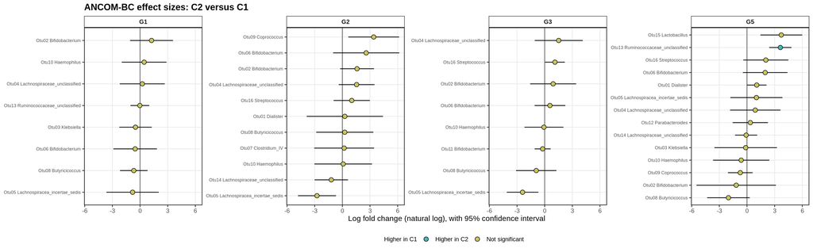

**Figure 9.** ANCOM-BC effect size (log fold change, C2 versus C1) of each OTU with its 95% confidence interval, run separately in each included study.

**How to read it.** A point to the right of zero means the OTU is more abundant in C2, to the left in C1. Of 51 OTU-by-study estimates, 41 are usable. One has an unadjusted p-value below 0.05: Otu13 Ruminococcaceae_unclassified, higher in C2 in G5. None is significant after adjustment (q < 0.05). ANCOM-BC uses a more cautious test than the bars suggest, so a bar that misses zero is not necessarily significant.

### Random-effects meta-analysis (metafor, REML) for every OTU

**The idea.** Each study is small, but there are several of them. ANCOM-BC gave, for each OTU in each study, an effect size (log fold change) and its standard error. A meta-analysis combines the study estimates of one OTU into one pooled effect size. It has two parts: a check of **which estimates can be pooled**, and the **random-effects model (REM)**, fitted with `metafor::rma(method = "REML")`, which does the pooling.

This is a different check from MetaQC at the start of the chapter: MetaQC decided which *studies* are combined; this step decides which *estimates* of those studies can be used.

**Part 1: which estimates can be pooled.** A pooled result is only as good as what goes into it, so three checks come first.

- **Is each estimate usable?** An estimate is kept only if ANCOM-BC could really test the OTU in that study: it has a log fold change, a standard error and a p-value. OTUs found in only one condition, or in a single sample of each condition, are left out.
- **Are there enough studies?** An OTU is pooled only if at least three studies have a usable estimate. With one or two studies there is nothing to compare.
- **Are the studies comparable?** MetaQC has already removed the study that was not homogeneous with the others. The remaining studies were processed with the same mothur pipeline and the same reference, so their OTUs mean the same thing. They still differ in read depth (see the first figure of this chapter) and in one filtering threshold (G5 used 97% identity). These differences are a reason to prefer a random-effects model and to check each result with one study left out.

**Part 2: the random-effects model (REM).** A *fixed-effect* model assumes that all studies measure exactly the same true effect and differ only by chance. A *random-effects* model is more realistic here: it assumes that each study has its own true effect, and that these true effects scatter around an average. That average is the pooled effect size.

- Each study estimate = average effect + how far this study’s true effect is from the average + sampling error.
- **tau²** is the variance of the true effects between studies. If tau² is 0 the random-effects model gives the same answer as the fixed-effect model.
- **REML.** tau² is estimated by restricted maximum likelihood (`method = "REML"`), the default in metafor. With few studies, plain maximum likelihood underestimates tau²; REML corrects for that.
- Each study gets the **weight** 1 / (standard error² + tau²). Precise studies count more, but a large tau² makes the weights more equal, so no single study dominates.
- **estimate** is the weighted average of the study effect sizes, with a 95% confidence interval. An interval that includes 0 is compatible with no difference.
- **I²** is the percentage of the total variation that comes from real differences between studies and not from chance; the **Q test** asks whether there is more variation than chance alone would give. These two are the quality control of the pooled result itself.

Two OTUs are first worked through by hand so that you can see every step. Then one function repeats exactly the same steps for all OTUs.

130

Before pooling: for every OTU, list which studies give a usable estimate and whether the OTU can be pooled.

“usable” means ANCOM-BC could test the OTU in that study; “not testable” means the OTU was present but in too few samples; “not detected” means it was seen in fewer than two samples of that study. An OTU needs at least three usable studies.

R code

```
qc_meta <- expand.grid(feature = unique(ancom$feature), study = studies, stringsAsFactors = FALSE)
found <- match(paste(qc_meta$feature, qc_meta$study), paste(ancom$feature, ancom$study))
qc_meta$status <- ifelse(is.na(found), "Not detected", ifelse(ancom$usable[found], "Usable", "Not testable"))
qc_meta$taxon <- unname(taxon_label[qc_meta$feature])
qc_summary <- as.data.frame.matrix(table(qc_meta$taxon, factor(qc_meta$status, levels = c("Usable", "Not testable", "Not detected"))))
qc_summary$pooled <- ifelse(qc_summary$Usable >= 3, "yes", "no")
write.csv(qc_meta, file.path(out_dir, "meta_qc.csv"), row.names = FALSE)
print(qc_summary)
```

Output

```
                                    Usable Not testable Not detected pooled
Otu01 Dialister                          2            1            1     no
Otu02 Bifidobacterium                    4            0            0    yes
Otu03 Klebsiella                         2            0            2     no
Otu04 Lachnospiraceae_unclassified       4            0            0    yes
Otu05 Lachnospiracea_incertae_sedis      4            0            0    yes
Otu06 Bifidobacterium                    4            0            0    yes
Otu07 Clostridium_IV                     1            1            2     no
Otu08 Butyricicoccus                     4            0            0    yes
Otu09 Coprococcus                        2            1            1     no
Otu10 Haemophilus                        4            0            0    yes
Otu11 Bifidobacterium                    1            0            3     no
Otu12 Parabacteroides                    1            0            3     no
Otu13 Ruminococcaceae_unclassified       2            1            1     no
Otu14 Lachnospiraceae_unclassified       2            1            1     no
Otu15 Lactobacillus                      1            1            2     no
Otu16 Streptococcus                      3            1            0    yes
Otu17 Lachnospiraceae_unclassified       0            1            3     no
Otu21 Clostridium_XlVa                   0            1            3     no
Otu24 Streptococcus                      0            1            3     no
```

131

Before pooling: draw the same information as a map of OTUs by studies.

R code

```
qc_meta$status <- factor(qc_meta$status, levels = c("Usable", "Not testable", "Not detected"))
usable_count <- tapply(qc_meta$status == "Usable", qc_meta$taxon, sum)
qc_meta$taxon <- factor(qc_meta$taxon, levels = names(sort(usable_count)))
qc_meta_plot <- ggplot(qc_meta, aes(study, taxon, fill = status)) +
  geom_tile(colour = "black") +
  geom_hline(yintercept = sum(usable_count < 3) + 0.5, linewidth = 1.2) +
  scale_fill_manual(values = c("Usable" = condition_colours[["C2"]], "Not testable" = not_significant_colour, "Not detected" = "white")) +
  labs(title = "Estimates available for pooling", subtitle = "OTUs above the thick line have a usable estimate in at least three studies and are pooled",
       x = "Study", y = NULL, fill = "ANCOM-BC estimate") +
  theme(panel.grid = element_blank(), plot.subtitle = element_text(size = 9))
ggsave(file.path(out_dir, "meta_qc.png"), qc_meta_plot, width = 9, height = 6.5, dpi = 180)
print(qc_meta_plot)
```

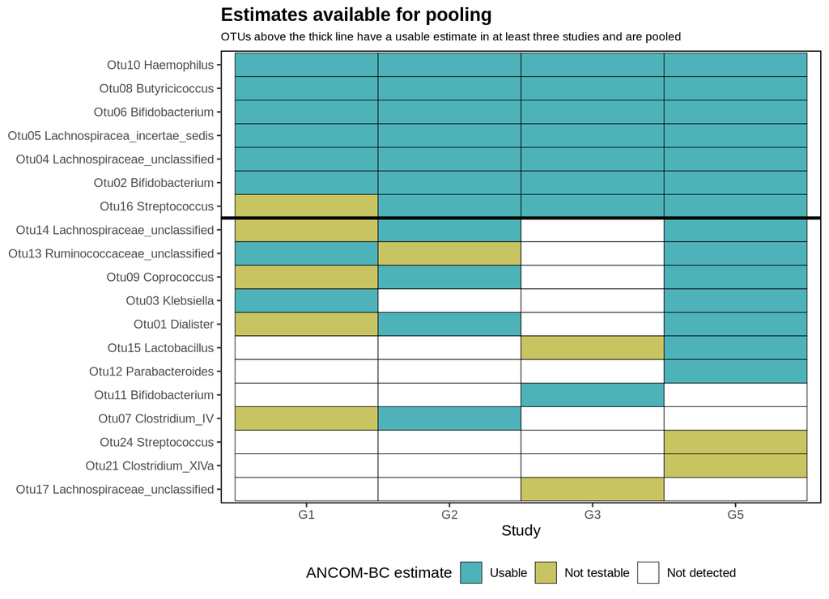

**Figure 10.** Estimates available for pooling: which included studies give a usable ANCOM-BC estimate for each OTU.

**How to read it.** Each row is an OTU and each column a study. Teal means a usable estimate, olive means the OTU was present but could not be tested, white means it was not detected. The seven OTUs above the thick line have at least three usable studies and go into the random-effects model; the twelve below do not. Six OTUs are usable in all four studies.

132

Example 1, Otu05: take its ANCOM-BC effect sizes from the included studies.

R code

```
example_1 <- ancom[ancom$feature == "Otu05" & ancom$usable, ]
print(example_1[, c("study", "taxon", "lfc_C2_vs_C1", "se", "p_value")], row.names = FALSE, digits = 3)
```

Output

```
 study                               taxon lfc_C2_vs_C1    se p_value
    G1 Otu05 Lachnospiracea_incertae_sedis       -0.809 1.449  0.6155
    G2 Otu05 Lachnospiracea_incertae_sedis       -2.753 1.052  0.0793
    G3 Otu05 Lachnospiracea_incertae_sedis       -2.401 0.876  0.1114
    G5 Otu05 Lachnospiracea_incertae_sedis        1.022 1.441  0.5293
```

133

Example 1, Otu05: fit the random-effects model and print the pooled effect size.

R code

```
model_1 <- rma(yi = lfc_C2_vs_C1, sei = se, data = example_1, method = "REML")
print(model_1)
```

Output

```
Random-Effects Model (k = 4; tau^2 estimator: REML)

tau^2 (estimated amount of total heterogeneity): 1.1815 (SE = 2.0925)
tau (square root of estimated tau^2 value):      1.0870
I^2 (total heterogeneity / total variability):   46.70%
H^2 (total variability / sampling variability):  1.88

Test for Heterogeneity:
Q(df = 3) = 5.5807, p-val = 0.1339

Model Results:

estimate      se     zval    pval    ci.lb   ci.ub
 -1.5160  0.8002  -1.8945  0.0582  -3.0843  0.0524  .

---
Signif. codes:  0 ‘***’ 0.001 ‘**’ 0.01 ‘*’ 0.05 ‘.’ 0.1 ‘ ’ 1
```

134

Example 1, Otu05: draw the forest plot and save it. Each square is one study; the diamond is the pooled effect size.

R code

```
forest_1 <- function() forest(model_1, slab = example_1$study, header = c("Study", "Log fold change [95% CI]"),
  xlab = "Log fold change, C2 versus C1", main = taxon_label[["Otu05"]], colout = "black",
  col = condition_colours[[ifelse(coef(model_1) > 0, "C2", "C1")]], border = "black")
forest_1()
png(file.path(out_dir, "meta_example_Otu05.png"), width = 1500, height = 850, res = 180)
forest_1()
invisible(dev.off())
```

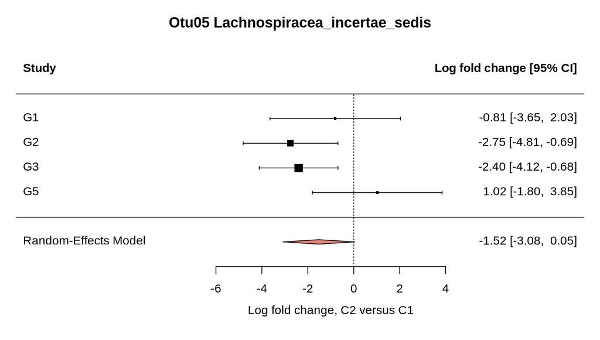

**Figure 11.** Forest plot of Otu05 Lachnospiracea_incertae_sedis.

**How to read it.** Each square is the ANCOM-BC effect size in one study and the line is its 95% confidence interval; larger squares are more precise and get more weight. The diamond is the pooled effect size. Three of the four studies point towards C1, but G5 points the other way. The pooled log fold change is −1.52 (95% CI −3.08 to 0.05, p = 0.058), with moderate heterogeneity (I² = 47%). Leaving G5 out gives −2.24 (95% CI −3.43 to −1.04): the one study filtered at 97% identity decides whether this OTU looks significant.

135

Example 1, Otu05: quality control of the pooled result. Refit the model once per study, each time leaving that study out.

If the pooled effect size stays on the same side of zero whichever study is removed, the result does not depend on one study. This matters most for G5, which was filtered at a different identity threshold.

R code

```
leave_one_out <- leave1out(model_1)
print(data.frame(left_out = example_1$study, estimate = leave_one_out$estimate, ci_lower = leave_one_out$ci.lb, ci_upper = leave_one_out$ci.ub,
                 p_value = leave_one_out$pval, I_squared = leave_one_out$I2), row.names = FALSE, digits = 3)
```

Output

```
 left_out estimate ci_lower ci_upper  p_value I_squared
       G1   -1.609    -3.69    0.473 0.129842      64.2
       G2   -0.978    -3.02    1.061 0.347086      53.1
       G3   -1.018    -3.25    1.211 0.370784      56.1
       G5   -2.237    -3.43   -1.040 0.000249       0.0
```

136

Example 2, Otu16: take its ANCOM-BC effect sizes from the included studies.

R code

```
example_2 <- ancom[ancom$feature == "Otu16" & ancom$usable, ]
print(example_2[, c("study", "taxon", "lfc_C2_vs_C1", "se", "p_value")], row.names = FALSE, digits = 3)
```

Output

```
 study               taxon lfc_C2_vs_C1    se p_value
    G2 Otu16 Streptococcus         1.02 1.002   0.385
    G3 Otu16 Streptococcus         1.11 0.546   0.134
    G5 Otu16 Streptococcus         2.04 1.246   0.176
```

137

Example 2, Otu16: fit the random-effects model and print the pooled effect size.

R code

```
model_2 <- rma(yi = lfc_C2_vs_C1, sei = se, data = example_2, method = "REML")
print(model_2)
```

Output

```
Random-Effects Model (k = 3; tau^2 estimator: REML)

tau^2 (estimated amount of total heterogeneity): 0 (SE = 0.7592)
tau (square root of estimated tau^2 value):      0
I^2 (total heterogeneity / total variability):   0.00%
H^2 (total variability / sampling variability):  1.00

Test for Heterogeneity:
Q(df = 2) = 0.5162, p-val = 0.7725

Model Results:

estimate      se    zval    pval   ci.lb   ci.ub
  1.2147  0.4472  2.7161  0.0066  0.3382  2.0913  **

---
Signif. codes:  0 ‘***’ 0.001 ‘**’ 0.01 ‘*’ 0.05 ‘.’ 0.1 ‘ ’ 1
```

138

Example 2, Otu16: draw the forest plot and save it.

R code

```
forest_2 <- function() forest(model_2, slab = example_2$study, header = c("Study", "Log fold change [95% CI]"),
  xlab = "Log fold change, C2 versus C1", main = taxon_label[["Otu16"]], colout = "black",
  col = condition_colours[[ifelse(coef(model_2) > 0, "C2", "C1")]], border = "black")
forest_2()
png(file.path(out_dir, "meta_example_Otu16.png"), width = 1500, height = 850, res = 180)
forest_2()
invisible(dev.off())
```

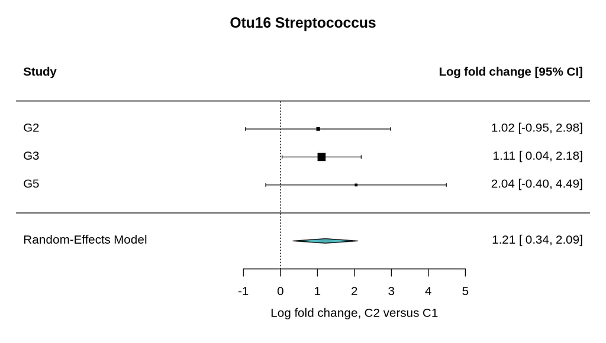

**Figure 12.** Forest plot of Otu16 Streptococcus.

**How to read it.** Otu16 has a usable estimate in three studies (G2, G3, G5), and all three point towards C2. The studies agree (tau² = 0, I² = 0%), so the random-effects model gives the same answer as a fixed-effect model: a pooled log fold change of +1.21 (95% CI 0.34 to 2.09, p = 0.007). It is the only OTU that stays significant after adjustment for the seven OTUs tested (adjusted p = 0.046).

139

All OTUs: write one function that does for any OTU what the two examples did by hand.

The quality-control rule is built in: an OTU is pooled only if at least three studies have a usable estimate; otherwise it is recorded as not estimable (NA). The function also returns tau², I² and the p-value of the Q test, so the heterogeneity of every pooled result can be checked.

R code

```
pool_otu <- function(feature) {
  d <- ancom[ancom$feature == feature & ancom$usable, ]
  not_estimable <- data.frame(feature = feature, studies = nrow(d), estimate = NA, se = NA, ci_lower = NA, ci_upper = NA,
                              p_value = NA, tau_squared = NA, I_squared = NA, Q_p_value = NA)
  if (nrow(d) < 3) return(not_estimable)
  model <- tryCatch(rma(yi = lfc_C2_vs_C1, sei = se, data = d, method = "REML"), error = function(e) NULL)
  if (is.null(model)) return(not_estimable)
  data.frame(feature = feature, studies = model$k, estimate = as.numeric(coef(model)), se = model$se, ci_lower = model$ci.lb,
             ci_upper = model$ci.ub, p_value = model$pval, tau_squared = model$tau2, I_squared = model$I2, Q_p_value = model$QEp)
}
```

140

All OTUs: apply the function to every OTU, adjust the p-values for multiple testing and save the table.

R code

```
meta_otu <- do.call(rbind, lapply(unique(ancom$feature), pool_otu))
meta_otu$adjusted_p <- p.adjust(meta_otu$p_value, "BH")
meta_otu$taxon <- unname(taxon_label[meta_otu$feature])
meta_otu$direction <- ifelse(is.na(meta_otu$p_value) | meta_otu$p_value >= significance_level, "Not significant",
                             ifelse(meta_otu$estimate > 0, "Higher in C2", "Higher in C1"))
meta_otu$direction <- factor(meta_otu$direction, levels = names(direction_colours))
meta_otu <- meta_otu[order(meta_otu$p_value), ]
write.csv(meta_otu, file.path(out_dir, "meta_otu_ancombc.csv"), row.names = FALSE)
print(meta_otu[, c("taxon", "studies", "estimate", "ci_lower", "ci_upper", "p_value", "adjusted_p", "tau_squared", "I_squared", "Q_p_value")], row.names = FALSE, digits = 3)
```

Output

```
                               taxon studies  estimate ci_lower ci_upper p_value adjusted_p tau_squared I_squared Q_p_value
                 Otu16 Streptococcus       3  1.214735   0.3382   2.0913 0.00661     0.0462    0.00e+00  0.00e+00     0.773
 Otu05 Lachnospiracea_incertae_sedis       4 -1.515952  -3.0843   0.0524 0.05816     0.1140    1.18e+00  4.67e+01     0.134
               Otu02 Bifidobacterium       4  1.130163  -0.0699   2.3302 0.06492     0.1140    0.00e+00  0.00e+00     0.712
  Otu04 Lachnospiraceae_unclassified       4  1.112597  -0.0697   2.2949 0.06513     0.1140    0.00e+00  0.00e+00     0.850
                Otu08 Butyricicoccus       4 -0.891441  -1.9187   0.1358 0.08897     0.1246    0.00e+00  0.00e+00     0.679
               Otu06 Bifidobacterium       4  0.823514  -0.3041   1.9511 0.15232     0.1777    2.78e-07  1.91e-05     0.371
                   Otu10 Haemophilus       4 -0.000996  -1.2887   1.2867 0.99879     0.9988    0.00e+00  0.00e+00     0.960
                     Otu01 Dialister       2        NA       NA       NA      NA         NA          NA        NA        NA
                    Otu03 Klebsiella       2        NA       NA       NA      NA         NA          NA        NA        NA
                Otu07 Clostridium_IV       1        NA       NA       NA      NA         NA          NA        NA        NA
                   Otu09 Coprococcus       2        NA       NA       NA      NA         NA          NA        NA        NA
  Otu13 Ruminococcaceae_unclassified       2        NA       NA       NA      NA         NA          NA        NA        NA
  Otu14 Lachnospiraceae_unclassified       2        NA       NA       NA      NA         NA          NA        NA        NA
               Otu11 Bifidobacterium       1        NA       NA       NA      NA         NA          NA        NA        NA
                 Otu15 Lactobacillus       1        NA       NA       NA      NA         NA          NA        NA        NA
  Otu17 Lachnospiraceae_unclassified       0        NA       NA       NA      NA         NA          NA        NA        NA
               Otu12 Parabacteroides       1        NA       NA       NA      NA         NA          NA        NA        NA
              Otu21 Clostridium_XlVa       0        NA       NA       NA      NA         NA          NA        NA        NA
                 Otu24 Streptococcus       0        NA       NA       NA      NA         NA          NA        NA        NA
```

141

All OTUs: draw the pooled effect size of every OTU with its 95% confidence interval.

R code

```
pooled <- meta_otu[!is.na(meta_otu$estimate), ]
pooled$label <- sprintf("%s  (k = %d)%s", pooled$taxon, pooled$studies, ifelse(pooled$adjusted_p < 0.05, " *", ""))
meta_plot <- ggplot(pooled, aes(estimate, reorder(label, estimate), fill = direction)) +
  geom_vline(xintercept = 0, colour = "grey40") +
  geom_errorbar(aes(xmin = ci_lower, xmax = ci_upper), width = 0, orientation = "y") +
  geom_point(shape = 23, size = 4, colour = "black") +
  scale_fill_manual(values = direction_colours, drop = FALSE) +
  labs(title = "Pooled effect size per OTU", subtitle = "Random-effects meta-analysis of ANCOM-BC log fold changes; k = number of studies; * adjusted p < 0.05",
       x = "Pooled log fold change, C2 versus C1, with 95% confidence interval", y = NULL, fill = NULL) +
  theme(plot.subtitle = element_text(size = 9))
ggsave(file.path(out_dir, "meta_otu_ancombc.png"), meta_plot, width = 10, height = 0.34 * nrow(pooled) + 2.4, dpi = 180)
print(meta_plot)
```

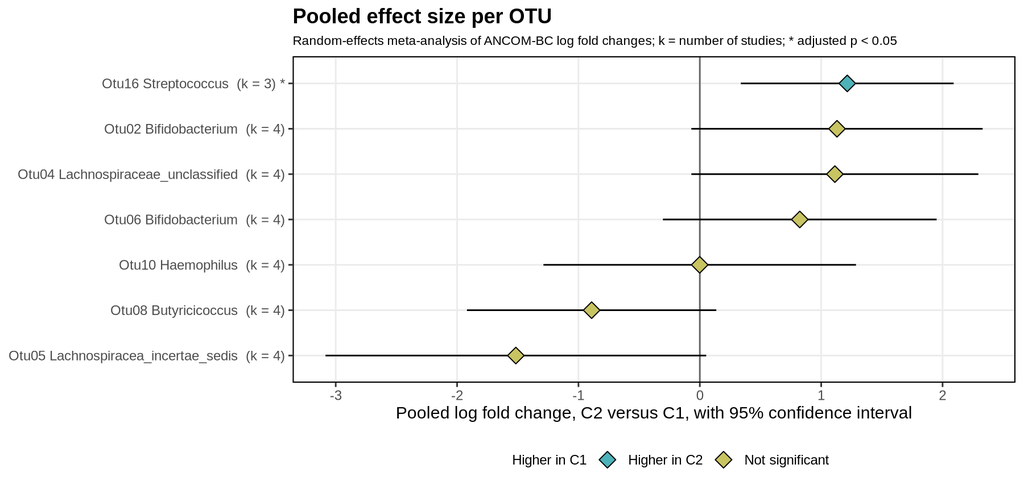

**Figure 13.** Pooled effect size per OTU from the random-effects meta-analysis (REML) of the ANCOM-BC estimates.

**How to read it.** Each diamond is the pooled effect across the included studies and the line is its 95% confidence interval; k is the number of studies that contributed. Teal and salmon diamonds have a pooled p-value below 0.05; the star marks an OTU that is still significant after adjustment. Only Otu16 Streptococcus qualifies (higher in C2, adjusted p = 0.046). Otu05, Otu02 and Otu04 have pooled p-values between 0.05 and 0.07.

### One cladogram for all included studies, coloured from the ANCOM-BC results

**What a cladogram shows.** The taxonomy drawn as a tree: the inner ring is the kingdom, each step outwards is a lower rank (phylum, class, order, family, genus), and the outer nodes are the OTUs. Every OTU is labelled with its number and genus, and the phylum (bold) and family are written on the inner nodes.

**One tree, all included studies, two conditions.** All OTUs that ANCOM-BC analysed are in one tree. Outside the tree there is one ring of tiles per included study (G1 innermost). A tile is salmon when the OTU is higher in C1 in that study and teal when it is higher in C2; it is strongly coloured when the difference is significant and pale when it is not, and it is missing when the study has no usable estimate. The tree nodes show the pooled result of the included studies: salmon or teal when the pooled effect is significant, olive when it is not. A shaded sector marks each significant OTU.

142

Turn the taxonomy of the OTUs into tree coordinates: one row per node with its rank, its position around the circle and its parent.

R code

```
features <- unique(ancom$feature)
ranks <- cbind(tax_matrix[features, c("Kingdom", "Phylum", "Class", "Order", "Family", "Genus"), drop = FALSE], OTU = unname(taxon_label[features]))
ranks <- ranks[do.call(order, as.data.frame(ranks)), , drop = FALSE]
paths <- sapply(seq_len(ncol(ranks)), function(level) apply(ranks[, seq_len(level), drop = FALSE], 1, paste, collapse = ";"))
leaf_position <- seq_len(nrow(ranks))
nodes <- do.call(rbind, lapply(seq_len(ncol(ranks)), function(level) {
  first <- match(unique(paths[, level]), paths[, level])
  data.frame(path = paths[first, level], level = level - 1, name = ranks[first, level],
             position = as.numeric(tapply(leaf_position, factor(paths[, level], levels = unique(paths[, level])), function(p) mean(range(p)))),
             parent = if (level == 1) NA else paths[first, level - 1])
}))
nodes$feature <- ifelse(nodes$level == 6, rownames(ranks)[match(nodes$path, paths[, 7])], NA)
nodes$parent_position <- nodes$position[match(nodes$parent, nodes$path)]
```

143

Colour the tree nodes from the pooled ANCOM-BC effect sizes. A higher-rank node takes a colour when all the significant OTUs below it point the same way.

R code

```
nodes$direction <- as.character(meta_otu$direction[match(nodes$feature, meta_otu$feature)])
for (i in which(is.na(nodes$feature))) {
  below <- rownames(ranks)[paths[, nodes$level[i] + 1] == nodes$path[i]]
  hits <- setdiff(unique(as.character(meta_otu$direction[match(below, meta_otu$feature)])), "Not significant")
  nodes$direction[i] <- if (length(hits) == 1) hits else "Not significant"
}
nodes$direction <- factor(nodes$direction, levels = names(direction_colours))
```

144

Make the ring tiles: one tile per OTU and study, coloured by the condition in which the OTU is higher.

R code

```
tiles <- ancom[ancom$usable, ]
tiles$position <- match(tiles$feature, rownames(ranks))
tiles$ring <- 8.9 + 0.55 * match(tiles$study, studies)
tiles$higher_in <- ifelse(tiles$lfc_C2_vs_C1 > 0, "C2", "C1")
tiles$significant <- tiles$p_value < significance_level
```

145

Draw the cladogram and save it.

`coord_polar()` bends the tree into a circle. Adding 2 to every rank leaves an open ring in the centre, so the inner nodes are not crowded. Tip labels are turned so that they can be read from the outside.

R code

```
n <- nrow(ranks)
tips <- nodes[!is.na(nodes$feature), ]
angle <- 90 - 360 * (tips$position - 0.5) / n
tips$hjust <- ifelse(angle < -90, 1, 0)
tips$angle <- ifelse(angle < -90, angle + 180, angle)
inner <- nodes[nodes$level %in% c(1, 4), ]
sectors <- tips[tips$direction != "Not significant", ]
branches <- nodes[!is.na(nodes$parent), ]
ring_labels <- data.frame(position = 0, ring = 8.9 + 0.55 * seq_along(studies), label = studies)
cladogram_plot <- ggplot(nodes) +
  geom_rect(data = sectors, aes(xmin = position - 0.5, xmax = position + 0.5, ymin = 2, ymax = 8.4, fill = direction), alpha = 0.25, show.legend = FALSE) +
  geom_segment(data = branches, aes(x = position, xend = position, y = level + 1, yend = level + 2), linewidth = 0.5) +
  geom_segment(data = branches, aes(x = parent_position, xend = position, y = level + 1, yend = level + 1), linewidth = 0.5) +
  geom_point(aes(position, level + 2, fill = direction, size = is.na(feature)), shape = 21, colour = "black", show.legend = c(fill = TRUE, size = FALSE)) +
  geom_tile(data = tiles, aes(position, ring, fill = paste("Higher in", higher_in), alpha = significant), width = 0.9, height = 0.5, colour = "black", linewidth = 0.2, show.legend = FALSE) +
  geom_text(data = ring_labels, aes(position, ring, label = label), size = 2.4, fontface = "bold") +
  geom_label(data = inner, aes(position, level + 2, label = name, fontface = ifelse(level == 1, "bold", "plain")), size = 3,
             vjust = -0.6, fill = "white", alpha = 0.7, linewidth = 0, label.padding = unit(0.08, "lines")) +
  geom_text(data = tips, aes(position, 12.1, label = name, angle = angle, hjust = hjust, fontface = ifelse(direction == "Not significant", "plain", "bold")), size = 3.6) +
  scale_fill_manual(values = direction_colours, drop = FALSE, name = NULL,
                    labels = c("Higher in C1", "Higher in C2", "Not significant")) +
  scale_alpha_manual(values = c(`TRUE` = 1, `FALSE` = 0.3)) +
  scale_size_manual(values = c(`TRUE` = 3, `FALSE` = 5)) +
  scale_x_continuous(limits = c(-0.5, n + 0.5)) + scale_y_continuous(limits = c(0, 18)) +
  coord_polar(theta = "x", clip = "off") +
  labs(title = "Cladogram of all included studies, coloured by condition",
       subtitle = paste0("Tree nodes: pooled ANCOM-BC result. Rings ", paste(studies, collapse = ", "), " (inside to outside): condition in which the OTU is higher in each study (strong colour = p < 0.05)")) +
  theme_void(base_size = 13) +
  theme(plot.title = element_text(face = "bold", hjust = 0.5), plot.subtitle = element_text(hjust = 0.5, size = 10), legend.position = "bottom",
        plot.background = element_rect(fill = "white", colour = NA), plot.margin = margin(10, 30, 10, 30)) +
  guides(fill = guide_legend(override.aes = list(size = 5)))
ggsave(file.path(out_dir, "ancombc_cladogram.png"), cladogram_plot, width = 12, height = 12.5, dpi = 180)
print(cladogram_plot)
```

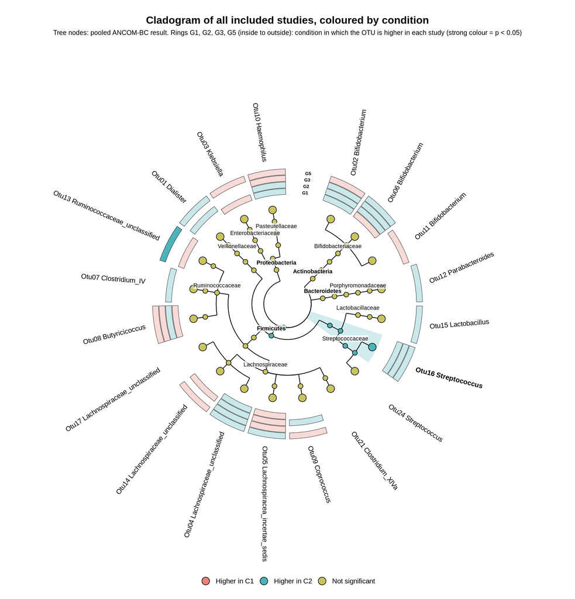

**Figure 14.** One cladogram for all included studies, coloured by condition from the ANCOM-BC results.

**How to read it.** Read the tree from the centre outwards: phylum (bold), class, order, family (named), genus, then the OTU with its name. Tree nodes show the pooled result: salmon is higher in C1, teal is higher in C2, olive is not significant. Otu16 Streptococcus (higher in C2) is the one coloured OTU, marked by a shaded sector, and its family and order take the same colour. The four rings outside the tree are the included studies, G1 innermost to G5 outermost. A salmon tile means the OTU is higher in C1 in that study, a teal tile higher in C2; a missing tile means no usable estimate. Only one tile is strongly coloured (p < 0.05): Otu13 in G5.

### Effect size of alpha diversity across the included studies

**The idea.** The same random-effects model is applied to alpha diversity. For each index and study the effect size is the mean difference, C2 minus C1; its variance comes from the spread within each condition. The quality-control rule here is that a study needs a variance above 0 to be weighted.

**Keep in mind.** One study group was filtered at 97% identity and the others at 99%. Differences between studies may therefore reflect filtering as well as biology.

146

Calculate the C2-minus-C1 difference and its variance for every index and study.

R code

```
alpha_effects <- do.call(rbind, lapply(names(alpha_metrics), function(metric) do.call(rbind, lapply(studies, function(s) {
  x <- alpha[alpha$study == s, metric]
  data.frame(metric = metric, study = s, effect = mean(x[4:6]) - mean(x[1:3]), variance = var(x[1:3]) / 3 + var(x[4:6]) / 3)
}))))
print(alpha_effects, row.names = FALSE, digits = 3)
```

Output

```
          metric study  effect variance
        observed    G1 -2.0000   0.2222
        observed    G2 -0.6667   1.7778
        observed    G3  0.6667   2.4444
        observed    G5  4.0000  45.2222
           chao1    G1 -0.1667   4.8056
           chao1    G2 -0.5000   4.0833
           chao1    G3  0.6667   2.4444
           chao1    G5 -0.3333 279.8611
         shannon    G1 -0.5104   0.1641
         shannon    G2 -0.4890   0.0338
         shannon    G3 -0.0633   0.0844
         shannon    G5  0.3081   0.2693
 inverse_simpson    G1 -1.2240   1.3655
 inverse_simpson    G2 -1.5571   0.2676
 inverse_simpson    G3 -0.4407   0.7890
 inverse_simpson    G5  0.0166   0.7554
```

147

Pool the included studies for every index with a random-effects model.

A study in which all six samples have the same value has a variance of 0 and cannot be weighted, so it is left out.

R code

```
alpha_models <- lapply(setNames(names(alpha_metrics), names(alpha_metrics)), function(metric)
  rma(yi = effect, vi = variance, data = alpha_effects[alpha_effects$metric == metric & alpha_effects$variance > 0, ], method = "REML"))
meta_alpha <- do.call(rbind, lapply(names(alpha_models), function(metric) { model <- alpha_models[[metric]]
  data.frame(metric = metric, studies = model$k, estimate = as.numeric(coef(model)), ci_lower = model$ci.lb, ci_upper = model$ci.ub,
             p_value = model$pval, tau_squared = model$tau2, I_squared = model$I2) }))
write.csv(meta_alpha, file.path(out_dir, "meta_alpha.csv"), row.names = FALSE)
print(meta_alpha, row.names = FALSE, digits = 3)
```

Output

```
          metric studies estimate ci_lower ci_upper p_value tau_squared I_squared
        observed       4   -1.090   -2.665  0.48500  0.1750      0.9363      34.9
           chao1       4    0.132   -1.974  2.23873  0.9021      0.0000       0.0
         shannon       4   -0.314   -0.624 -0.00342  0.0475      0.0146      12.9
 inverse_simpson       4   -0.956   -1.811 -0.10144  0.0283      0.1459      18.1
```

148

Draw the forest plots of the four indices and save them.

R code

```
forest_alpha <- function() {
  old_par <- par(mfrow = c(2, 2), mar = c(4.5, 2, 3, 2))
  for (metric in names(alpha_models)) {
    model <- alpha_models[[metric]]
    forest(model, slab = alpha_effects$study[alpha_effects$metric == metric & alpha_effects$variance > 0], header = "Study",
           xlab = "Difference, C2 minus C1", main = alpha_metrics[[metric]], colout = "black",
           col = condition_colours[[ifelse(coef(model) > 0, "C2", "C1")]], border = "black")
  }
  par(old_par)
}
forest_alpha()
png(file.path(out_dir, "meta_alpha_forest.png"), width = 2400, height = 1500, res = 180)
forest_alpha()
invisible(dev.off())
```

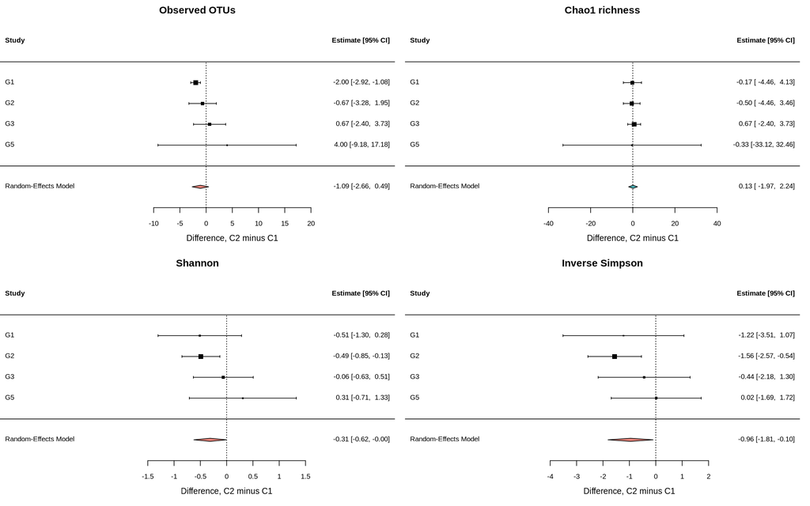

**Figure 15.** Forest plots of the C2-minus-C1 difference in the four alpha-diversity indices, pooled over the included studies.

#### Check your understanding

**What does a low IQC score tell you about a study?**

That its co-abundance structure (which OTUs rise and fall together) differs from that of the other studies more than they differ from each other. Combining such a study with the others mixes different things, which is why MetaQC excluded G4.

**Why can no study pass CQC or AQC here, and is that a reason to exclude all of them?**

Consistency and accuracy need a clear C1-versus-C2 signal in each study, and three samples per condition cannot give one. It is a limit of the data, not of the studies, so the decision rests on IQC, which does not depend on the condition labels.

**Why is ANCOM-BC run separately in each study instead of on one merged table?**

Studies differ in sequencing depth, filtering and population. On a merged table those differences can look like differences between conditions. Run per study, each estimate compares C1 and C2 within the same study, and the meta-analysis then combines the estimates.

**Why was LEfSe replaced by ANCOM-BC?**

With three samples per condition LEfSe’s first test cannot pass after adjustment, so it reports nothing. ANCOM-BC corrects for compositional bias and gives every OTU an effect size with a standard error, which is exactly what a meta-analysis needs.

**What is the difference between a fixed-effect and a random-effects model, and what does REML do?**

A fixed-effect model assumes every study measures the same true effect. A random-effects model lets the true effect differ between studies and estimates how much (tau²). REML is the method used to estimate tau²; with few studies it is less biased than plain maximum likelihood.

**Otu16 is not significant in any single study, but it is in the pooled analysis. How is that possible?**

Each study alone is too small to give a precise estimate. All three estimates point the same way, and combining them gives a narrower confidence interval than any single study has.

**One study group was filtered at 97% identity. Why does that matter for the pooled results?**

A looser threshold keeps different reads, so a difference between G5 and the other studies may come from the filtering and not from biology. In the forest plot of Otu05, G5 is the one study that points the other way, and leaving it out makes the pooled effect significant.

## Glossary

**16S rRNA gene**

A gene found in all bacteria. Parts of it are nearly identical everywhere (good for primers) and parts vary between groups (good for telling bacteria apart).

**Read pair**

Two sequences read from opposite ends of the same DNA fragment: forward (R1) and reverse (R2).

**Contig**

One sequence made by joining an overlapping forward and reverse read.

**FASTA / FASTQ**

Text formats for sequences. FASTQ also stores a quality score for every base.

**Count table**

mothur file recording how many times each unique sequence occurs in each sample.

**Chimera**

An artificial sequence made of two different templates during PCR.

**OTU**

Operational taxonomic unit: a cluster of sequences that are at least 97% similar.

**ASV**

Amplicon sequence variant: one exact unique sequence treated as a feature.

**Phylotype**

A group of sequences that share the same taxonomic name.

**Shared file**

mothur's feature table: one row per sample, one column per OTU, ASV or phylotype.

**Relative abundance**

A feature's count divided by the sample's total, so samples of different depth can be compared.

**Subsampling (rarefying)**

Randomly drawing the same number of reads from every sample to equalise depth.

**Alpha diversity**

Diversity within one sample (observed OTUs, Shannon, inverse Simpson).

**Beta diversity**

Difference in composition between two samples (for example Bray–Curtis).

**PCoA**

Principal coordinates analysis: a map of samples in which map distance approximates dissimilarity.

**PERMANOVA**

A permutation test of whether groups of samples differ in composition, based on a distance matrix.

**Chao1**

An estimate of the true number of OTUs in a sample, including those that were probably missed, based on the OTUs seen only once or twice.

**Bray–Curtis**

A distance between two samples based on OTU abundances; dominated by the common OTUs.

**Canberra**

A distance based on abundances in which every OTU has the same weight, so rare OTUs matter.

**Jclass**

The Jaccard distance on presence or absence: the share of OTUs that the two samples do not have in common.

**ThetaYC**

The Yue & Clayton distance, which compares community structure using the proportions of all OTUs.

**PERMDISP**

A permutation test of whether the samples of one group are more spread out than those of another.

**MetaQC**

An R package that scores each study of a meta-analysis on six quality measures (IQC, EQC, CQCg, CQCp, AQCg, AQCp) to decide objectively which studies can be combined.

**IQC**

Internal quality control: whether a study has the same co-abundance structure as the other studies (homogeneity).

**CQC**

Consistency quality control: whether a study ranks features (CQCg) or groups (CQCp) by their difference between conditions in the same order as the other studies combined.

**REML**

Restricted maximum likelihood, the method metafor uses by default to estimate the between-study variance tau².

**ANCOM-BC**

A differential-abundance method that corrects for the bias of compositional data and reports a log fold change with a standard error for each feature.

**Effect size**

How large a difference is, as opposed to how certain it is. Here: the log fold change of an OTU, or the C2-minus-C1 difference of a diversity index.

**Log fold change**

The natural logarithm of the ratio between two abundances. 0 means equal; 0.69 means twice as much.

**Forest plot**

A figure showing the estimate and confidence interval of each study and the pooled estimate underneath.

**Cladogram**

A tree drawing of the taxonomy, used here to show where the differing OTUs sit.

**p-value adjustment (BH)**

The Benjamini–Hochberg correction, which limits false discoveries when many tests are run.

**Random-effects meta-analysis**

Pooling of estimates from several studies while allowing the true effect to vary between them.

**Exploratory**

Useful for learning and for generating ideas, but not strong enough to support a firm conclusion.